# Halls Cave Temporal Analysis

### 7.3. Dataframe of the Change

```r
time.dat.change = data.frame(Interval_ID=1:16,
                      interval=names(interval_dat),
                      interval.start=interval.start,
                      interval.end=interval.end,
                      connectance.change = sum.data$connectance -lead(sum.data$connectance),
                      TM.change = time_mods-lead(time_mods),
                      Tavg.change = climate_dat$Calculated_Average_Temp-lead(climate_dat$Calculated_Average_Temp),
                      SpC.change = spp_count-lead(spp_count),
                      Pr.change = climate_dat$CCSM_Precip_mm-lead(climate_dat$CCSM_Precip_mm),
                      Tmax.change = climate_dat$CCSM_Max_Temp_C-lead(climate_dat$CCSM_Max_Temp_C),
                      Tmax_SD.change = climate_dat$CCSM_Max_Temp_SD-lead(climate_dat$CCSM_Max_Temp_SD),
                      Tmin.change = climate_dat$CCSM_Min_Temp_C-lead(climate_dat$CCSM_Min_Temp_C),
                      Tmin_SD.change = climate_dat$CCSM_Min_Temp_SD-lead(climate_dat$CCSM_Min_Temp_SD),
                      PrCv.change = climate_dat$CCSM_Precip_CV-lead(climate_dat$CCSM_Precip_CV)) %>%
  mutate(interval.mid=(interval.start+interval.end)/2)
```

Add the Δ Climate Data sum.data

```r
sum.data$spp.richness.change = spp_count-lead(spp_count)

sum.data$web.modularity.change = time_mods-lead(time_mods)

sum.data$Tavg.change = climate_dat$Calculated_Average_Temp-lead(climate_dat$Calculated_Average_Temp)

sum.data$Tmax.change = climate_dat$CCSM_Max_Temp_C-lead(climate_dat$CCSM_Max_Temp_C)

sum.data$Tmax_SD.change = climate_dat$CCSM_Max_Temp_SD-lead(climate_dat$CCSM_Max_Temp_SD)

sum.data$Tmin.change = climate_dat$CCSM_Min_Temp_C-lead(climate_dat$CCSM_Min_Temp_C)

sum.data$Tmin_SD.change = climate_dat$CCSM_Min_Temp_SD-lead(climate_dat$CCSM_Min_Temp_SD)

sum.data$Pr.change = climate_dat$CCSM_Precip_mm-lead(climate_dat$CCSM_Precip_mm)

sum.data$PrCv.change = climate_dat$CCSM_Precip_CV-lead(climate_dat$CCSM_Precip_CV)

sum.data$Connectance.change = sum.data$connectance-lead(sum.data$connectance)

sum.data$NOS.change = sum.data$NOS-lead(sum.data$NOS)


sum.data
```

```
##                 interval.name interval.start interval.end spp.richness
## 0-1128ybp           0-1128ybp              0        -1128           43
## 1128-1458ybp     1128-1458ybp          -1128        -1458           36
## 1458-2775ybp     1458-2775ybp          -1458        -2775           38
## 3104-4422ybp     3104-4422ybp          -3104        -4422           36
## 4751-6069ybp     4751-6069ybp          -4751        -6069           31
## 6398-7716ybp     6398-7716ybp          -6398        -7716           34
## 8045-9363ybp     8045-9363ybp          -8045        -9363           38
## 9692-11010ybp   9692-11010ybp          -9692       -11010           47
## 11339-12656ybp 11339-12656ybp         -11339       -12656           57
## 12986-14623ybp 12986-14623ybp         -12986       -14623           60
## 14859-15802ybp 14859-15802ybp         -14859       -15802           59
## 16038-16980ybp 16038-16980ybp         -16038       -16980           51
## 17216-18159ybp 17216-18159ybp         -17216       -18159           40
## 18395-19338ybp 18395-19338ybp         -18395       -19338           25
## 19574-20517ybp 19574-20517ybp         -19574       -20517           32
## 20752-20988ybp 20752-20988ybp         -20752       -20988           29
##                web.modularity         NOS connectance int_diversity
## 0-1128ybp          0.12386667  0.10224823   0.5500000      4.595120
## 1128-1458ybp       0.07022940  0.37610132   0.7124183      4.691348
## 1458-2775ybp       0.06501146  0.42032443   0.7309942      4.828314
## 3104-4422ybp       0.07290906  0.54162801   0.7916667      4.736198
## 4751-6069ybp       0.11121962  0.65625000   1.0000000      4.158883
## 6398-7716ybp       0.15695694  0.40099010   0.7156863      4.290459
## 8045-9363ybp       0.13601928  0.44565217   0.7000000      4.430817
## 9692-11010ybp      0.07013744  0.45058275   0.6736111      5.267858
## 11339-12656ybp     0.06914262  0.18619531   0.4847826      5.407172
## 12986-14623ybp     0.22000000 -0.00444171   0.4044118      5.105945
## 14859-15802ybp     0.14598161  0.08608389   0.3920000      4.990433
## 16038-16980ybp     0.24828125  0.08851707   0.5023923      4.653960
## 17216-18159ybp     0.53168044 -0.06796117   0.3406593      3.433987
## 18395-19338ybp     0.35102041  0.16037736   0.3589744      2.639057
## 19574-20517ybp     0.45841210  0.13227513   0.3571429      2.995732
## 20752-20988ybp     0.42630385 -0.06952124   0.3454545      2.944439
##                interval.mid NOS.mean.null NOS.lower_ci NOS.upper_ci
## 0-1128ybp            -564.0  -0.014745048   -0.1819023   0.21170362
## 1128-1458ybp        -1293.0  -0.006835466   -0.1851854   0.24229891
## 1458-2775ybp        -2116.5  -0.010692389   -0.1832061   0.23283514
## 3104-4422ybp        -3763.0  -0.007358561   -0.1916575   0.24694408
## 4751-6069ybp        -5410.0   0.040427784   -0.1872402   0.33854167
```

[output cut: 98 more lines]

```
## 1128-1458ybp         -0.018575851 -0.044223106
## 1458-2775ybp         -0.060672515 -0.121303587
## 3104-4422ybp         -0.208333333 -0.114621985
## 4751-6069ybp          0.284313725  0.255259901
## 6398-7716ybp          0.015686275 -0.044662075
## 8045-9363ybp          0.026388889 -0.004930577
## 9692-11010ybp         0.188828502  0.264387439
## 11339-12656ybp        0.080370844  0.190637022
## 12986-14623ybp        0.012411765 -0.090525601
## 14859-15802ybp       -0.110392344 -0.002433179
## 16038-16980ybp        0.161733004  0.156478235
## 17216-18159ybp       -0.018315018 -0.228338524
## 18395-19338ybp        0.001831502  0.028102226
## 19574-20517ybp        0.011688312  0.201796375
## 20752-20988ybp                 NA           NA
```

### 7.4. Plotting Climate and Modularity

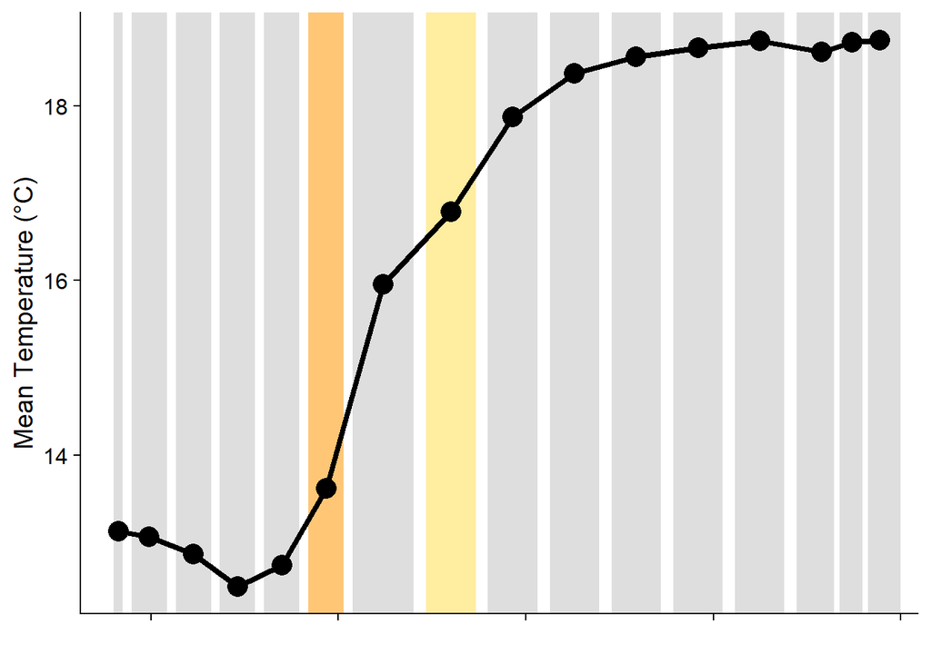

```r
#just raw temperature across time

temp.plot = ggplot(data=time.dat, aes(x=-interval.mid)) +
  geom_rect(xmin=interval.start, xmax=interval.end, ymin=-0.3, ymax=Inf, fill="gray", alpha=0.5) +
  geom_rect(xmin=interval.start[9], xmax=interval.end[9], ymin=-0.3, ymax=Inf, fill="#ffeda0", alpha=0.5) +
      geom_rect(xmin=interval.start[11], xmax=interval.end[11], ymin=-0.3, ymax=Inf, fill="#ffc675", alpha=0.5) +
  geom_vline(xintercept = 950.0, color = "white", size=1.5) +
  geom_vline(xintercept = 1700.0, color = "white", size=1.5) +
  geom_point(aes(y=Tavg), color="black", size=5) +
  geom_line(aes(y=Tavg), lwd=1.5) +
  scale_color_manual(values=c("black")) +
  theme_cowplot() +
  scale_x_reverse()+
  xlab("Time Interval (year before present)") +
  ylab("Mean Temperature (°C)")+
  theme(axis.text.x=element_blank()) +
  xlab("")

temp.plot
```

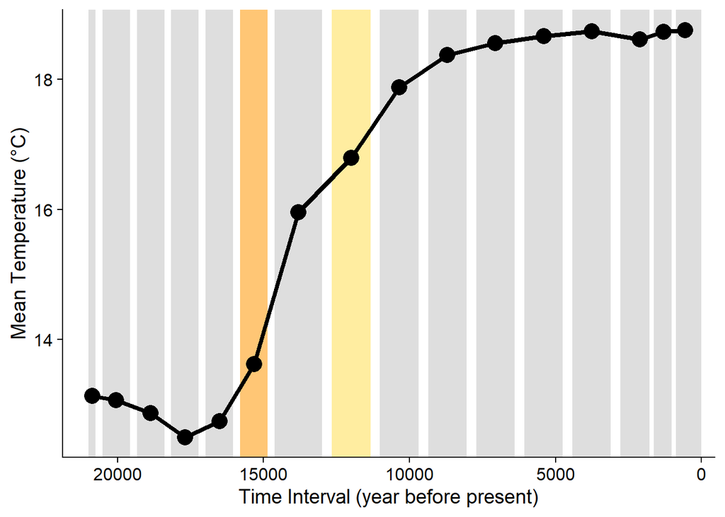

```r
temp.plot_2 = ggplot(data=time.dat, aes(x=-interval.mid)) +
  geom_rect(xmin=interval.start, xmax=interval.end, ymin=-0.3, ymax=Inf, fill="gray", alpha=0.5) +
  geom_rect(xmin=interval.start[9], xmax=interval.end[9], ymin=-0.3, ymax=Inf, fill="#ffeda0", alpha=0.5) +
      geom_rect(xmin=interval.start[11], xmax=interval.end[11], ymin=-0.3, ymax=Inf, fill="#ffc675", alpha=0.5) +
  geom_vline(xintercept = 950.0, color = "white", size=1.5) +
  geom_vline(xintercept = 1700.0, color = "white", size=1.5) +
  geom_point(aes(y=Tavg), color="black", size=5) +
  geom_line(aes(y=Tavg), lwd=1.5) +
  scale_color_manual(values=c("black")) +
  theme_cowplot() +
  scale_x_reverse()+
  xlab("Time Interval (year before present)") +
  ylab("Mean Temperature (°C)")

temp.plot_2
```

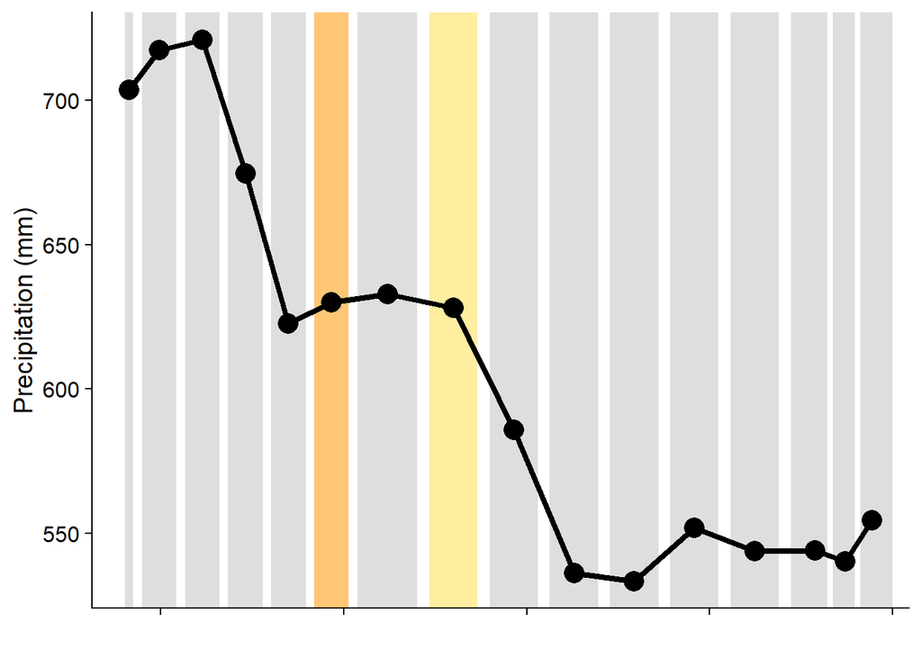

```r
# Plotting precipitation  over time

precip.plot = ggplot(data=time.dat, aes(x=-interval.mid)) +
  geom_rect(xmin=interval.start, xmax=interval.end, ymin=-60, ymax=Inf, fill="gray", alpha=0.5) +
  geom_rect(xmin=interval.start[9], xmax=interval.end[9], ymin=-60, ymax=Inf, fill="#ffeda0", alpha=0.5) +
      geom_rect(xmin=interval.start[11], xmax=interval.end[11], ymin=-60, ymax=Inf, fill="#ffc675", alpha=0.5) +
  geom_vline(xintercept = 950.0, color = "white", size=1.5) +
  geom_vline(xintercept = 1700.0, color = "white", size=1.5) +
  geom_point(aes(y=Pr), color="black", size=5) +
  geom_line(aes(y=Pr), lwd=1.5) +
  scale_color_manual(values=c("black")) +
  theme_cowplot() +
  scale_x_reverse() +
  xlab("Time Interval (year before present)") +
  ylab("Precipitation (mm)") +
  theme(axis.text.x=element_blank()) +
  xlab("")

precip.plot
```

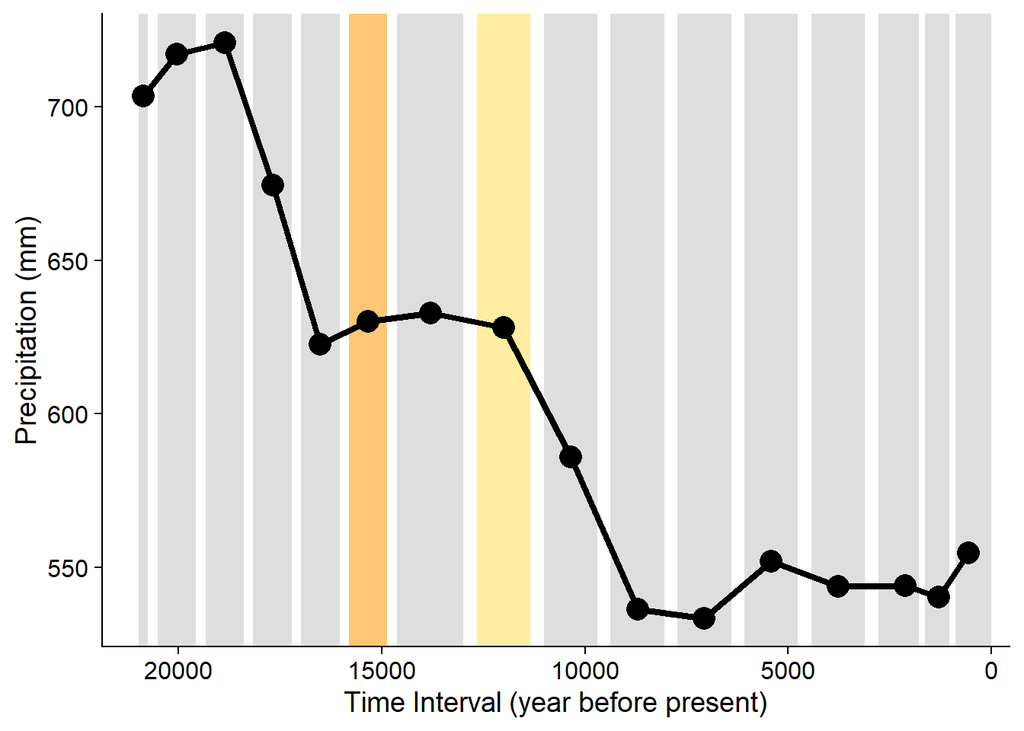

```r
precip.plot_2 = ggplot(data=time.dat, aes(x=-interval.mid)) +
  geom_rect(xmin=interval.start, xmax=interval.end, ymin=-60, ymax=Inf, fill="gray", alpha=0.5) +
  geom_rect(xmin=interval.start[9], xmax=interval.end[9], ymin=-60, ymax=Inf, fill="#ffeda0", alpha=0.5) +
      geom_rect(xmin=interval.start[11], xmax=interval.end[11], ymin=-60, ymax=Inf, fill="#ffc675", alpha=0.5) +
  geom_vline(xintercept = 950.0, color = "white", size=1.5) +
  geom_vline(xintercept = 1700.0, color = "white", size=1.5) +
  geom_point(aes(y=Pr), color="black", size=5) +
  geom_line(aes(y=Pr), lwd=1.5) +
  scale_color_manual(values=c("black")) +
  theme_cowplot() +
  scale_x_reverse() +
  xlab("Time Interval (year before present)") +
  ylab("Precipitation (mm)")

precip.plot_2
```

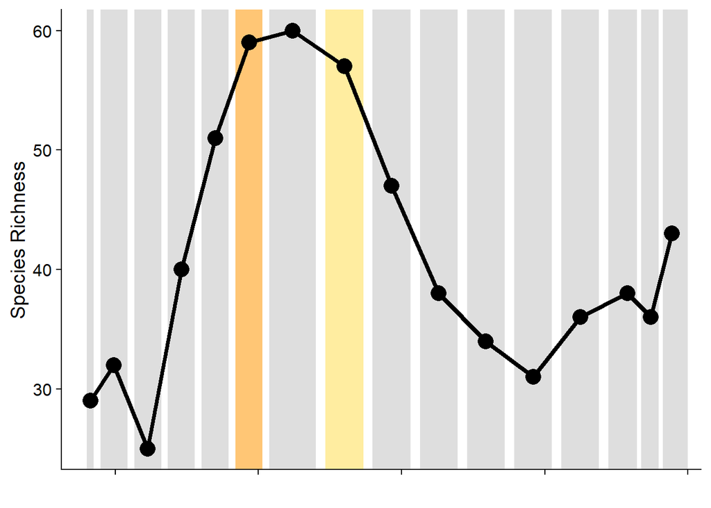

```r
# Plotting the raw species richness (spc) over time

spcraw.plot = ggplot(data=time.dat, aes(x=-interval.mid)) +
  geom_rect(xmin=interval.start, xmax=interval.end, ymin=-25, ymax=Inf, fill="gray", alpha=0.5) +
  geom_rect(xmin=interval.start[9], xmax=interval.end[9], ymin=-25, ymax=Inf, fill="#ffeda0", alpha=0.5) +
      geom_rect(xmin=interval.start[11], xmax=interval.end[11], ymin=-25, ymax=Inf, fill="#ffc675", alpha=0.5) +
  geom_vline(xintercept = 950.0, color = "white", size=1.5) +
  geom_vline(xintercept = 1700.0, color = "white", size=1.5) +
  geom_point(aes(y=SpC), color="black", size=5) +
  geom_line(aes(y=SpC), lwd=1.5) +
  scale_color_manual(values=c("black")) +
  theme_cowplot() +
  scale_x_reverse() +
  xlab("Time Interval (year before present)") +
  ylab("Species Richness")+
  theme(axis.text.x=element_blank()) +
  xlab("")

spcraw.plot
```

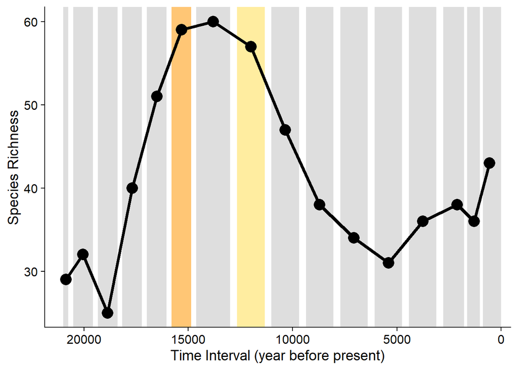

```r
spcraw.plot_2 = ggplot(data=time.dat, aes(x=-interval.mid)) +
  geom_rect(xmin=interval.start, xmax=interval.end, ymin=-25, ymax=Inf, fill="gray", alpha=0.5) +
  geom_rect(xmin=interval.start[9], xmax=interval.end[9], ymin=-25, ymax=Inf, fill="#ffeda0", alpha=0.5) +
      geom_rect(xmin=interval.start[11], xmax=interval.end[11], ymin=-25, ymax=Inf, fill="#ffc675", alpha=0.5) +
  geom_vline(xintercept = 950.0, color = "white", size=1.5) +
  geom_vline(xintercept = 1700.0, color = "white", size=1.5) +
  geom_point(aes(y=SpC), color="black", size=5) +
  geom_line(aes(y=SpC), lwd=1.5) +
  scale_color_manual(values=c("black")) +
  theme_cowplot() +
  scale_x_reverse() +
  xlab("Time Interval (year before present)") +
  ylab("Species Richness")

spcraw.plot_2
```

## 8. Plotting The Variables Together

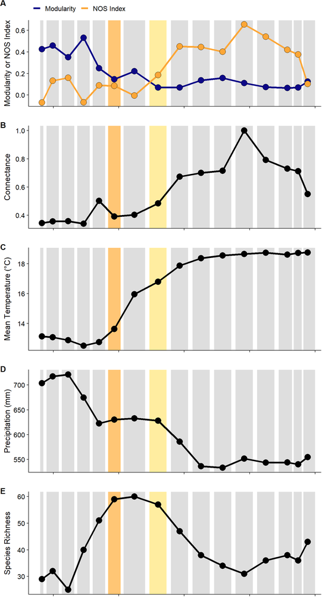

```r
plot_grid(mod.nos.plot_2, connectance.plot_2, temp.plot, precip.plot, spcraw.plot, nrow=5, labels = "AUTO", vjust = 1, hjust = -0.05, align="v")
```

## 9. Spearman-Rank Correlations

Spearman-Rank Correlation here is a non-parametric statistical test used to understand how well correlated a relationship between two variables. In this case, we will be testing the relationship between the change in temperature, precipitation, and species richness to the change we see in modularity over time.

Plots:

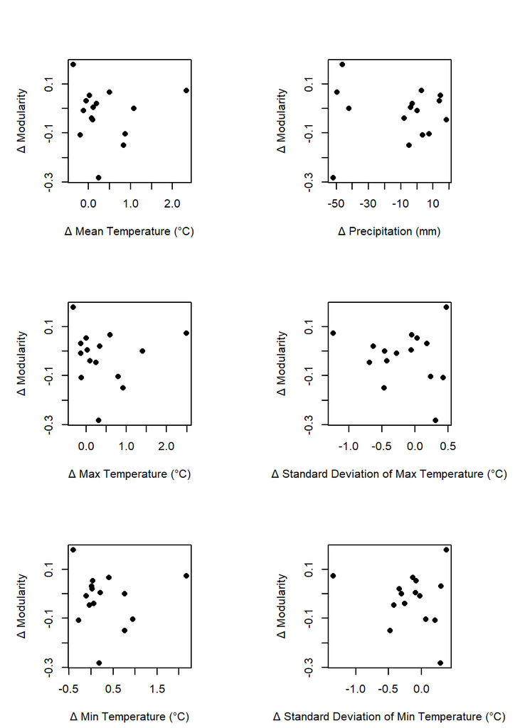

```r
par(mfrow=c(3,2), mar=c(1,5,1,5), pty = "s")

plot(time.dat.change$Tavg.change, time.dat.change$TM.change, type="p", col="black", pch=16, xlab = "Δ Mean Temperature (°C)", ylab = "Δ Modularity")

plot(time.dat.change$Pr.change, time.dat.change$TM.change, type="p", col="black", pch=16, xlab = "Δ Precipitation (mm)", ylab = "Δ Modularity")

plot(time.dat.change$Tmax.change, time.dat.change$TM.change, type="p", col="black", pch=16, xlab = "Δ Max Temperature (°C)", ylab = "Δ Modularity")

plot(time.dat.change$Tmax_SD.change, time.dat.change$TM.change, type="p", col="black", pch=16, xlab = "Δ Standard Deviation of Max Temperature (°C)", ylab = "Δ Modularity")

plot(time.dat.change$Tmin.change, time.dat.change$TM.change, type="p", col="black", pch=16, xlab = "Δ Min Temperature (°C)", ylab = "Δ Modularity")

plot(time.dat.change$Tmin_SD.change, time.dat.change$TM.change, type="p", col="black", pch=16, xlab = "Δ Standard Deviation of Min Temperature (°C)", ylab = "Δ Modularity")
```

```r
par(mfrow=c(1,1), pty = "s")
```

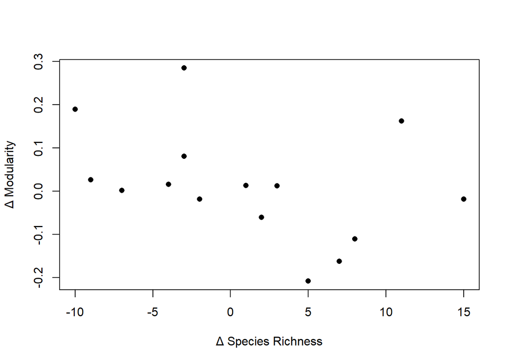

```r
plot(time.dat.change$SpC.change, time.dat.change$connectance.change, type="p", col="black", pch=16, xlab = "Δ Species Richness", ylab = "Δ Modularity")
```

### 9.1. So, what statistic correlates best with modularity?

Run spearman correlations and arrange results into table.

```r
key_stats <- c("Tavg.change", "Pr.change", "Tmax.change", "Tmax_SD.change", "Tmin.change", "Tmin_SD.change", "spp.richness.change");
spearman_summaries <- data.frame(stat=as.character(key_stats),rho=as.numeric(rep(0,length(key_stats))),pvalue=as.numeric(rep(0,length(key_stats))));
for (ks in 1:length(key_stats)) {
  spearman_test <- cor.test(sum.data[,match(key_stats[ks],colnames(sum.data))],sum.data$web.modularity.change,method="spearman");
spearman_summaries$rho[ks] <- round(spearman_test$estimate,3);
spearman_summaries$pvalue[ks] <- spearman_test$p.value;
if (spearman_summaries$pvalue[ks]>10^-2)  {
  spearman_summaries$pvalue[ks] <- round(spearman_summaries$pvalue[ks],3)
  } else  {
    spearman_summaries$pvalue[ks] <- round(spearman_summaries$pvalue[ks]/(10^floor(log10(spearman_summaries$pvalue[ks]))),2)*(10^floor(log10(spearman_summaries$pvalue[ks])))
  }
}
spearman_summaries$rho2 <- spearman_summaries$rho^2;

spearman_summaries
```

```
##                  stat    rho pvalue     rho2
## 1         Tavg.change -0.107  0.705 0.011449
## 2           Pr.change -0.004  0.995 0.000016
## 3         Tmax.change -0.150  0.593 0.022500
## 4      Tmax_SD.change -0.054  0.853 0.002916
## 5         Tmin.change -0.054  0.853 0.002916
## 6      Tmin_SD.change  0.007  0.985 0.000049
## 7 spp.richness.change  0.038  0.894 0.001444
```

Export as an excel file

```r
# write.xlsx(spearman_summaries, file = "Supplemental Data/Spearman_Correlations.xlsx",
#       sheetName = "Climate v Mod", append = FALSE)
```

## 10. Supplemental Analyses

### 10.1. Spearman Partial Correlations

Partial correlations tests the relationship between two variables while controlling for a third variable. Here, we test the correlation between modularity, temperature, precipitation, and species richness while controlling for each variable. *This method allows us to see if the correlation between the first and third variable is due to the direct correlations between 1 & 2 and 2 & 3*

```r
pcor_1 = pcor.test(na.exclude(time.dat.change$TM.change),na.exclude(time.dat.change$Tavg.change),na.exclude(time.dat.change$Pr.change),method="spearman");

pcor_2 = pcor.test(na.exclude(time.dat.change$TM.change),na.exclude(time.dat.change$Pr.change),na.exclude(time.dat.change$Tavg.change),method="spearman");

pcor_3 = pcor.test(na.exclude(time.dat.change$TM.change),na.exclude(time.dat.change$Tavg.change),na.exclude(time.dat.change$SpC.change),method="spearman");

pcor_4 = pcor.test(na.exclude(time.dat.change$TM.change),na.exclude(time.dat.change$SpC.change),na.exclude(time.dat.change$Tavg.change),method="spearman");

pcor_5 = pcor.test(na.exclude(time.dat.change$TM.change),na.exclude(time.dat.change$Pr.change),na.exclude(time.dat.change$SpC.change),method="spearman");

pcor_6 = pcor.test(na.exclude(time.dat.change$TM.change),na.exclude(time.dat.change$SpC.change),na.exclude(time.dat.change$Pr.change),method="spearman");

pcor_all = data.frame(rbind(pcor_1,pcor_2,pcor_3,pcor_4,pcor_5,pcor_6))

pcor_all$correlation <- c("Mod + Temp - Precip", "Mod + Precip - Temp", "Mod + Temp - Rich", "Mod + Rich - Temp", "Mod + Precip - Rich", 'Mod + Rich - Precip')

pcor_all
```

```
##       estimate   p.value   statistic  n gp   Method         correlation
## 1 -0.110177696 0.7076926 -0.38400459 15  1 spearman Mod + Temp - Precip
## 2 -0.026075632 0.9294924 -0.09035936 15  1 spearman Mod + Precip - Temp
## 3 -0.100570833 0.7322857 -0.35016295 15  1 spearman   Mod + Temp - Rich
## 4  0.005455180 0.9852334  0.01889758 15  1 spearman   Mod + Rich - Temp
## 5 -0.004447856 0.9879599 -0.01540798 15  1 spearman Mod + Precip - Rich
## 6  0.037626907 0.8983827  0.13043580 15  1 spearman Mod + Rich - Precip
```

Export as an excel file

```r
#write.xlsx(spearman_summaries, file = "Supplemental Data/Supplemental_Analyses.xlsx",
      #sheetName = "Partial Correlations", append = FALSE)
```

### 10.2. Multiple Regression

```r
multiple_regressions_all <- summary(lm(time.dat.change$TM.change ~ (time.dat.change$Tavg.change+time.dat.change$Pr.change+time.dat.change$SpC.change+time.dat.change$Tmax.change+time.dat.change$Tmax_SD.change+time.dat.change$Tmin.change+time.dat.change$Tmin_SD.change)));
multiple_regressions_all$r.squared;
```

```
## [1] 0.1091048
```

```r
multiple_regressions_all$adj.r.squared;
```

```
## [1] -0.5590665
```

```r
multiple_regressions_all$coefficients;
```

```
##                                     Estimate  Std. Error     t value  Pr(>|t|)
## (Intercept)                    -0.0154693992 0.047842781 -0.32333821 0.7547293
## time.dat.change$Tavg.change    -0.0422302130 0.583564415 -0.07236598 0.9440872
## time.dat.change$Pr.change      -0.0008109441 0.002081604 -0.38957660 0.7070155
## time.dat.change$SpC.change      0.0011085537 0.006233242  0.17784545 0.8632651
## time.dat.change$Tmax.change    -0.0567578576 0.562729250 -0.10086175 0.9221422
## time.dat.change$Tmax_SD.change  0.0853002837 0.271558744  0.31411356 0.7614698
## time.dat.change$Tmin_SD.change -0.2809948009 0.390957720 -0.71873450 0.4927601
```

```r
multiple_regressions_all$cov.unscaled;
```

```
##                                  (Intercept) time.dat.change$Tavg.change
## (Intercept)                     0.1213147368                  0.21068576
## time.dat.change$Tavg.change     0.2106857573                 18.04921549
## time.dat.change$Pr.change       0.0004255909                 -0.03379110
## time.dat.change$SpC.change     -0.0047992497                 -0.09158871
## time.dat.change$Tmax.change    -0.3024866826                -17.05286010
## time.dat.change$Tmax_SD.change  0.1617062863                 -3.28968298
## time.dat.change$Tmin_SD.change -0.2328890091                  2.73108991
##                                time.dat.change$Pr.change
## (Intercept)                                 0.0004255909
## time.dat.change$Tavg.change                -0.0337910969
## time.dat.change$Pr.change                   0.0002296555
## time.dat.change$SpC.change                  0.0001554878
## time.dat.change$Tmax.change                 0.0370951641
## time.dat.change$Tmax_SD.change              0.0029518248
## time.dat.change$Tmin_SD.change              0.0081090051
##                                time.dat.change$SpC.change
## (Intercept)                                 -0.0047992497
## time.dat.change$Tavg.change                 -0.0915887096
## time.dat.change$Pr.change                    0.0001554878
## time.dat.change$SpC.change                   0.0020592482
## time.dat.change$Tmax.change                  0.0879680041
## time.dat.change$Tmax_SD.change               0.0037438031
## time.dat.change$Tmin_SD.change              -0.0084920624
##                                time.dat.change$Tmax.change
## (Intercept)                                    -0.30248668
## time.dat.change$Tavg.change                   -17.05286010
## time.dat.change$Pr.change                       0.03709516
## time.dat.change$SpC.change                      0.08796800
## time.dat.change$Tmax.change                    16.78339076
## time.dat.change$Tmax_SD.change                  2.42080882
## time.dat.change$Tmin_SD.change                 -0.83674220
##                                time.dat.change$Tmax_SD.change
## (Intercept)                                       0.161706286
## time.dat.change$Tavg.change                      -3.289682978
## time.dat.change$Pr.change                         0.002951825
## time.dat.change$SpC.change                        0.003743803
## time.dat.change$Tmax.change                       2.420808817
## time.dat.change$Tmax_SD.change                    3.908483734
## time.dat.change$Tmin_SD.change                   -4.925365775
##                                time.dat.change$Tmin_SD.change
## (Intercept)                                      -0.232889009
## time.dat.change$Tavg.change                       2.731089912
## time.dat.change$Pr.change                         0.008109005
## time.dat.change$SpC.change                       -0.008492062
## time.dat.change$Tmax.change                      -0.836742201
## time.dat.change$Tmax_SD.change                   -4.925365775
## time.dat.change$Tmin_SD.change                    8.101031372
```

```r
multiple_regressions_all
```

```
##
## Call:
## lm(formula = time.dat.change$TM.change ~ (time.dat.change$Tavg.change +
##     time.dat.change$Pr.change + time.dat.change$SpC.change +
##     time.dat.change$Tmax.change + time.dat.change$Tmax_SD.change +
##     time.dat.change$Tmin.change + time.dat.change$Tmin_SD.change))
##
## Residuals:
##      Min       1Q   Median       3Q      Max
## -0.24024 -0.05611  0.01092  0.06448  0.17486
##
## Coefficients: (1 not defined because of singularities)
##                                  Estimate Std. Error t value Pr(>|t|)
## (Intercept)                    -0.0154694  0.0478428  -0.323    0.755
## time.dat.change$Tavg.change    -0.0422302  0.5835644  -0.072    0.944
## time.dat.change$Pr.change      -0.0008109  0.0020816  -0.390    0.707
## time.dat.change$SpC.change      0.0011086  0.0062332   0.178    0.863
## time.dat.change$Tmax.change    -0.0567579  0.5627292  -0.101    0.922
## time.dat.change$Tmax_SD.change  0.0853003  0.2715587   0.314    0.761
## time.dat.change$Tmin.change            NA         NA      NA       NA
## time.dat.change$Tmin_SD.change -0.2809948  0.3909577  -0.719    0.493
##
## Residual standard error: 0.1374 on 8 degrees of freedom
##   (1 observation deleted due to missingness)
## Multiple R-squared:  0.1091, Adjusted R-squared:  -0.5591
## F-statistic: 0.1633 on 6 and 8 DF,  p-value: 0.9799
```

### 10.3. Tabulate Trophic Categories

```r
categories=unique(spp_attrs$Trophic_Category)
for(i in 1:length(interval_dat_list)){
  interval_dat_list[[i]]$interval=i
}
interval_dat_all=bind_rows(interval_dat_list)
```

```r
troph_props=interval_dat_all %>%
  group_by(interval, Trophic_Category, .drop=FALSE) %>%
  count() %>%
  group_by(interval) %>%
  mutate(prop=n/sum(n)) %>%
  pivot_wider(id_cols=interval, names_from=Trophic_Category, values_from = prop) %>%
  replace(is.na(.), 0)

troph_props
```

```
## # A tibble: 16 × 9
## # Groups:   interval [16]
##    interval browser carnivore frugivore_granivore grazer insectivore omnivore
##       <int>   <dbl>     <dbl>               <dbl>  <dbl>       <dbl>    <dbl>
##  1        1   0.186    0.163               0.116  0.233       0.116    0.0698
##  2        2   0.25     0.194               0.111  0.0833      0.139    0.0833
##  3        3   0.237    0.184               0.158  0.0789      0.132    0.0789
##  4        4   0.25     0.222               0.139  0.0833      0.0833   0.0833
##  5        5   0.290    0.0968              0.194  0.0968      0.0968   0.0645
##  6        6   0.235    0.147               0.147  0.0882      0.147    0.0882
##  7        7   0.211    0.132               0.184  0.105       0.132    0.105
##  8        8   0.170    0.213               0.149  0.149       0.106    0.106
##  9        9   0.175    0.246               0.105  0.123       0.0877   0.140
## 10       10   0.167    0.167               0.1    0.15        0.133    0.15
## 11       11   0.169    0.169               0.102  0.153       0.136    0.119
## 12       12   0.216    0.137               0.0980 0.137       0.137    0.118
## 13       13   0.225    0.125               0.025  0.175       0.15     0.075
## 14       14   0.12     0.12                0.12   0.24        0.08     0.08
## 15       15   0.188    0.125               0.0938 0.219       0.0938   0.0938
## 16       16   0.276    0.172               0.0345 0.207       0        0.103
## # ℹ 2 more variables: `NA` <dbl>, `mixed feeder` <dbl>
```

```r
time.dat2=time.dat %>% left_join(troph_props, by=join_by("Interval_ID"=="interval")) %>%
  mutate(browswer.change=browser-lead(browser)) %>%
  mutate(carnivore.change=carnivore-lead(carnivore)) %>%
  mutate(frugivore_granivore.change=frugivore_granivore-lead(frugivore_granivore)) %>%
  mutate(grazer.change=grazer-lead(grazer)) %>%
  mutate(insectivore.change=insectivore-lead(insectivore)) %>%
  mutate(omnivore.change=omnivore-lead(omnivore))
time.dat2
```

```
##    Interval_ID       interval interval.start interval.end         TM SpC
## 1            1      0-1128ybp              0        -1128 0.12386667  43
## 2            2   1128-1458ybp          -1128        -1458 0.07022940  36
## 3            3   1458-2775ybp          -1458        -2775 0.06501146  38
## 4            4   3104-4422ybp          -3104        -4422 0.07290906  36
## 5            5   4751-6069ybp          -4751        -6069 0.11121962  31
## 6            6   6398-7716ybp          -6398        -7716 0.15695694  34
## 7            7   8045-9363ybp          -8045        -9363 0.13601928  38
## 8            8  9692-11010ybp          -9692       -11010 0.07013744  47
## 9            9 11339-12656ybp         -11339       -12656 0.06914262  57
## 10          10 12986-14623ybp         -12986       -14623 0.22000000  60
## 11          11 14859-15802ybp         -14859       -15802 0.14598161  59
## 12          12 16038-16980ybp         -16038       -16980 0.24828125  51
## 13          13 17216-18159ybp         -17216       -18159 0.53168044  40
## 14          14 18395-19338ybp         -18395       -19338 0.35102041  25
```

[output cut: 70 more lines]

```r
time.dat.change2=time.dat.change %>% left_join(time.dat2, by=join_by("Interval_ID"=="Interval_ID"))
```

```r
cor.test(time.dat2$TM, time.dat2$grazer)
```

```
##
##  Pearson's product-moment correlation
##
## data:  time.dat2$TM and time.dat2$grazer
## t = 3.3428, df = 14, p-value = 0.004833
## alternative hypothesis: true correlation is not equal to 0
## 95 percent confidence interval:
##  0.2546333 0.8734746
## sample estimates:
##       cor
## 0.6662433
```

```r
cor.test(time.dat2$TM, time.dat2$carnivore)
```

```
##
##  Pearson's product-moment correlation
##
## data:  time.dat2$TM and time.dat2$carnivore
## t = -2.384, df = 14, p-value = 0.03183
## alternative hypothesis: true correlation is not equal to 0
## 95 percent confidence interval:
##  -0.81576174 -0.05676179
## sample estimates:
##        cor
## -0.5373477
```

```r
cor.test(time.dat2$TM, time.dat2$browser)
```

```
##
##  Pearson's product-moment correlation
##
## data:  time.dat2$TM and time.dat2$browser
## t = -0.30423, df = 14, p-value = 0.7654
## alternative hypothesis: true correlation is not equal to 0
## 95 percent confidence interval:
##  -0.5544730  0.4320182
## sample estimates:
##         cor
## -0.08104274
```

```r
cor.test(time.dat2$TM, time.dat2$frugivore_granivore)
```

```
##
##  Pearson's product-moment correlation
##
## data:  time.dat2$TM and time.dat2$frugivore_granivore
## t = -3.9997, df = 14, p-value = 0.001317
## alternative hypothesis: true correlation is not equal to 0
## 95 percent confidence interval:
##  -0.9001315 -0.3676642
## sample estimates:
##        cor
## -0.7302747
```

```r
cor.test(time.dat2$TM, time.dat2$insectivore)
```

```
##
##  Pearson's product-moment correlation
##
## data:  time.dat2$TM and time.dat2$insectivore
## t = -0.9752, df = 14, p-value = 0.346
## alternative hypothesis: true correlation is not equal to 0
## 95 percent confidence interval:
##  -0.6647991  0.2782899
## sample estimates:
##        cor
## -0.2522074
```

```r
cor.test(time.dat2$TM, time.dat2$omnivore)
```

```
##
##  Pearson's product-moment correlation
##
## data:  time.dat2$TM and time.dat2$omnivore
## t = -0.29532, df = 14, p-value = 0.7721
## alternative hypothesis: true correlation is not equal to 0
## 95 percent confidence interval:
##  -0.5528268  0.4339470
## sample estimates:
##         cor
## -0.07868403
```

```r
cor.test(time.dat.change2$TM.change, time.dat.change2$browswer.change)
```

```
##
##  Pearson's product-moment correlation
##
## data:  time.dat.change2$TM.change and time.dat.change2$browswer.change
## t = 1.2816, df = 13, p-value = 0.2224
## alternative hypothesis: true correlation is not equal to 0
## 95 percent confidence interval:
##  -0.2140705  0.7231192
## sample estimates:
##       cor
## 0.3349198
```

```r
cor.test(time.dat.change2$TM.change, time.dat.change2$carnivore.change)
```

```
##
##  Pearson's product-moment correlation
##
## data:  time.dat.change2$TM.change and time.dat.change2$carnivore.change
## t = -1.3376, df = 13, p-value = 0.204
## alternative hypothesis: true correlation is not equal to 0
## 95 percent confidence interval:
##  -0.7300155  0.2000890
## sample estimates:
##        cor
## -0.3478253
```

```r
cor.test(time.dat.change2$TM.change, time.dat.change2$frugivore_granivore.change)
```

```
##
##  Pearson's product-moment correlation
##
## data:  time.dat.change2$TM.change and time.dat.change2$frugivore_granivore.change
## t = -2.1671, df = 13, p-value = 0.04938
## alternative hypothesis: true correlation is not equal to 0
## 95 percent confidence interval:
##  -0.812900920 -0.003936867
## sample estimates:
##        cor
## -0.5151608
```

```r
cor.test(time.dat.change2$TM.change, time.dat.change2$grazer.change)
```

```
##
##  Pearson's product-moment correlation
##
## data:  time.dat.change2$TM.change and time.dat.change2$grazer.change
## t = 0.23809, df = 13, p-value = 0.8155
## alternative hypothesis: true correlation is not equal to 0
## 95 percent confidence interval:
##  -0.4619650  0.5592761
## sample estimates:
##        cor
## 0.06589069
```

```r
cor.test(time.dat.change2$TM.change, time.dat.change2$insectivore.change)
```

```
##
##  Pearson's product-moment correlation
##
## data:  time.dat.change2$TM.change and time.dat.change2$insectivore.change
## t = 2.3359, df = 13, p-value = 0.03616
## alternative hypothesis: true correlation is not equal to 0
## 95 percent confidence interval:
##  0.04361513 0.82594111
## sample estimates:
##       cor
## 0.5437297
```

```r
cor.test(time.dat.change2$TM.change, time.dat.change2$omnivore.change)
```

```
##
##  Pearson's product-moment correlation
##
## data:  time.dat.change2$TM.change and time.dat.change2$omnivore.change
## t = -1.1695, df = 13, p-value = 0.2632
## alternative hypothesis: true correlation is not equal to 0
## 95 percent confidence interval:
##  -0.7087775  0.2419674
## sample estimates:
##        cor
## -0.3085391
```

```r
library(vegan)

distmat=vegdist(troph_props %>% dplyr::select(browser, carnivore, frugivore_granivore, grazer, insectivore, omnivore))
class(distmat)
```

```
## [1] "dist"
```

```r
trophic_turnover=sapply(1:15, function(x) as.matrix(distmat)[x,x+1])

cor.test(trophic_turnover, time.dat.change2$TM.change[1:15])
```

```
##
##  Pearson's product-moment correlation
##
## data:  trophic_turnover and time.dat.change2$TM.change[1:15]
## t = 0.8231, df = 13, p-value = 0.4253
## alternative hypothesis: true correlation is not equal to 0
## 95 percent confidence interval:
##  -0.3269809  0.6596206
## sample estimates:
##       cor
## 0.2225609
```

### 10.4. Temporal autocorrelation plots

```r
library(tseries)
```

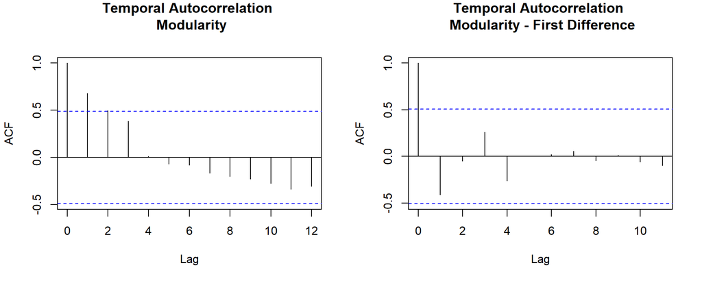

```r
par(mfrow=c(1,2))
acf(time.dat$TM, main="Temporal Autocorrelation \n Modularity")
acf(time.dat.change$TM.change[1:15], main="Temporal Autocorrelation \n Modularity - First Difference")
```

```r
par(mfrow=c(1,1))
```

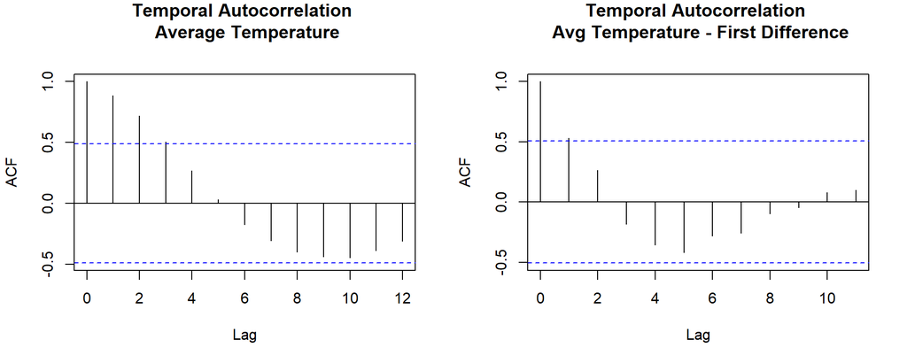

```r
par(mfrow=c(1,2))
acf(time.dat$Tavg, main="Temporal Autocorrelation \n Average Temperature")
acf(time.dat.change$Tavg.change[1:15], main="Temporal Autocorrelation \n Avg Temperature - First Difference")
```

```r
par(mfrow=c(1,1))
```

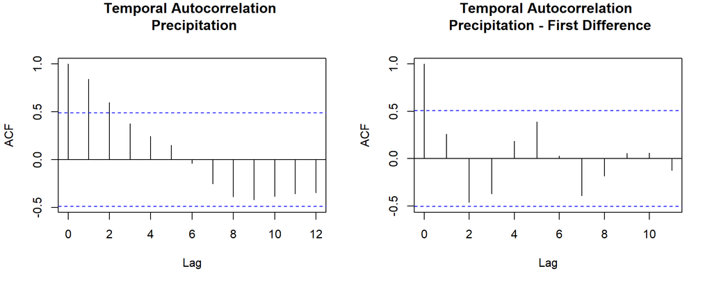

```r
par(mfrow=c(1,2))
acf(time.dat$Pr, main="Temporal Autocorrelation \n Precipitation")
acf(time.dat.change$Pr.change[1:15], main="Temporal Autocorrelation \n Precipitation - First Difference")
```

```r
par(mfrow=c(1,1))
```

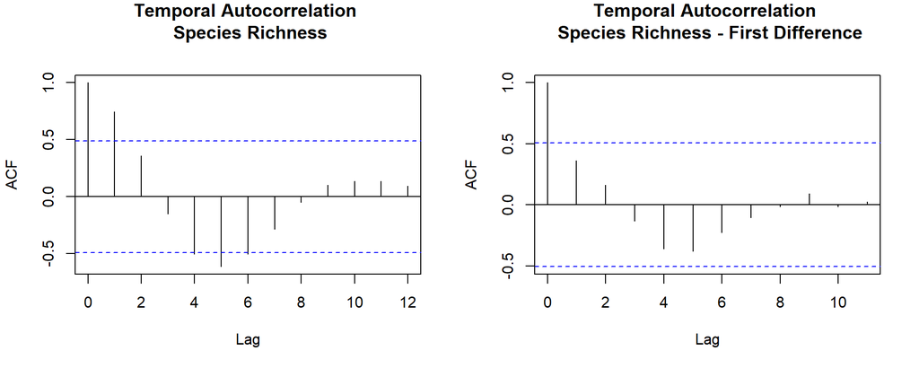

```r
par(mfrow=c(1,2))
acf(time.dat$SpC, main="Temporal Autocorrelation \n Species Richness")
acf(time.dat.change$SpC.change[1:15],  main="Temporal Autocorrelation \n Species Richness - First Difference")
```

```r
par(mfrow=c(1,1))
```

## 11. Testing Reviewer Suggestions

### Collapsing Figures:

#### 11.1. Plotting Variables

Fig. 3 and 5 (3 rows, 2 columns) - Raw Values Over Time

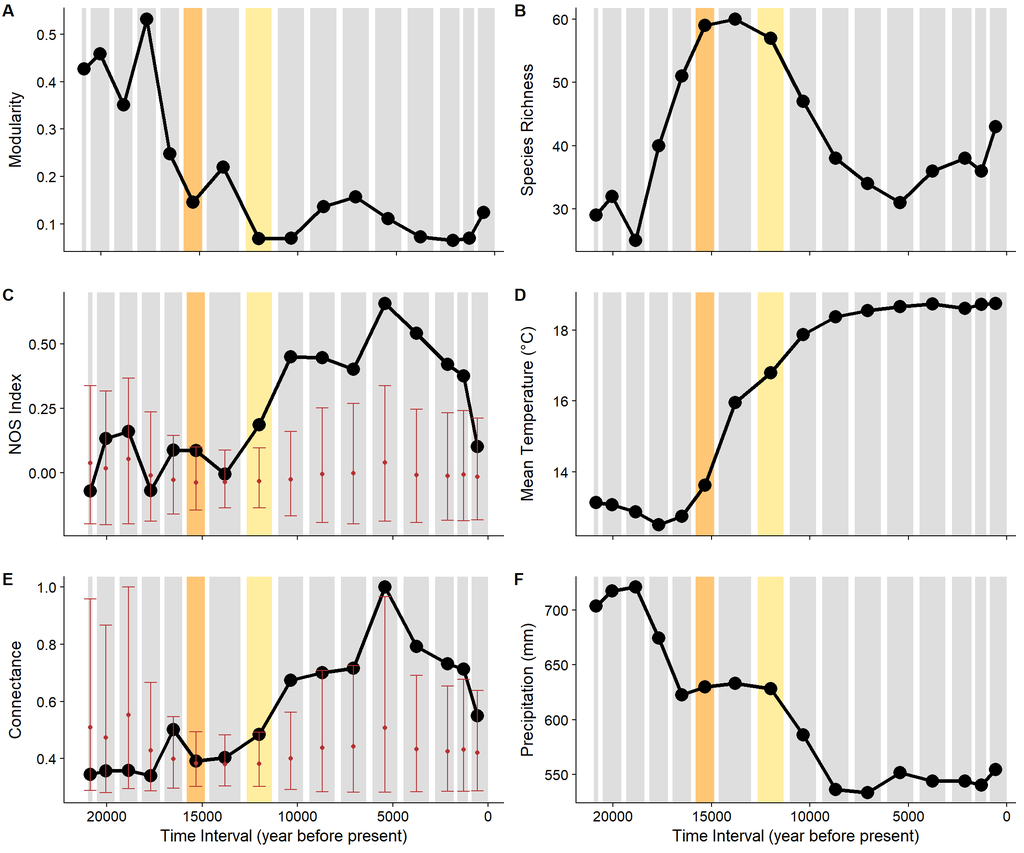

```r
plot_grid(mod.test, spcraw.plot, nos.null.plot, temp.plot, connectance.null.plot_2, precip.plot_2, nrow=3, ncol=2, labels = "AUTO", vjust = 1.3, hjust = -0.2, align="v")
```

Fig. 4 and 6

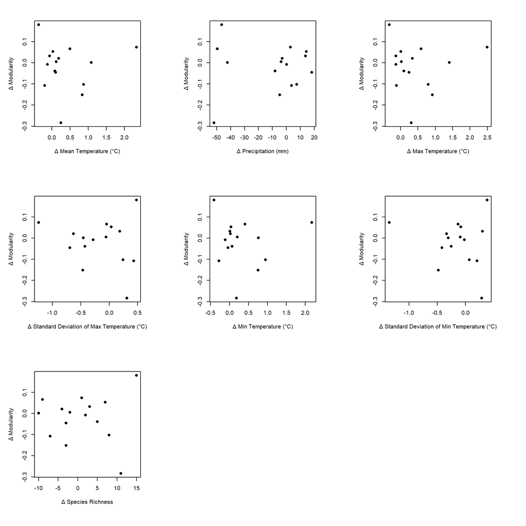

```r
par(mfrow=c(3,3), mar=c(5,5,1,5), pty = "s")

plot(sum.data$Tavg.change, sum.data$web.modularity.change, type="p", col="black", pch=16, xlab = "Δ Mean Temperature (°C)", ylab = "Δ Modularity")

plot(sum.data$Pr.change, sum.data$web.modularity.change, type="p", col="black", pch=16, xlab = "Δ Precipitation (mm)", ylab = "Δ Modularity")

plot(sum.data$Tmax.change, sum.data$web.modularity.change, type="p", col="black", pch=16, xlab = "Δ Max Temperature (°C)", ylab = "Δ Modularity")

plot(sum.data$Tmax_SD.change, sum.data$web.modularity.change, type="p", col="black", pch=16, xlab = "Δ Standard Deviation of Max Temperature (°C)", ylab = "Δ Modularity")

plot(sum.data$Tmin.change, sum.data$web.modularity.change, type="p", col="black", pch=16, xlab = "Δ Min Temperature (°C)", ylab = "Δ Modularity")

plot(sum.data$Tmin_SD.change, sum.data$web.modularity.change, type="p", col="black", pch=16, xlab = "Δ Standard Deviation of Min Temperature (°C)", ylab = "Δ Modularity")

plot(sum.data$spp.richness.change, sum.data$web.modularity.change, type="p", col="black", pch=16, xlab = "Δ Species Richness", ylab = "Δ Modularity")
```

#### 11.2. Modularity vs Connectance Correlations

Raw Data: Modularity vs Connectance Correlations and Plots

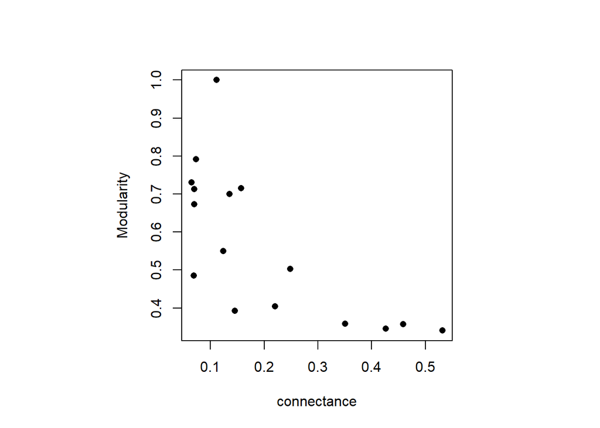

```r
par(mfrow=c(1,1), pty = "s")

plot(sum.data$web.modularity, sum.data$connectance, type="p", col="black", pch=16, xlab = "connectance", ylab = "Modularity")
```

```r
cor.test(sum.data$web.modularity, sum.data$connectance,method="spearman")
```

```
##
##  Spearman's rank correlation rho
##
## data:  sum.data$web.modularity and sum.data$connectance
## S = 1180, p-value = 0.001703
## alternative hypothesis: true rho is not equal to 0
## sample estimates:
##        rho
## -0.7352941
```

1st Difference Data: Δ Modularity vs Δ Connectance Correlations and Plots

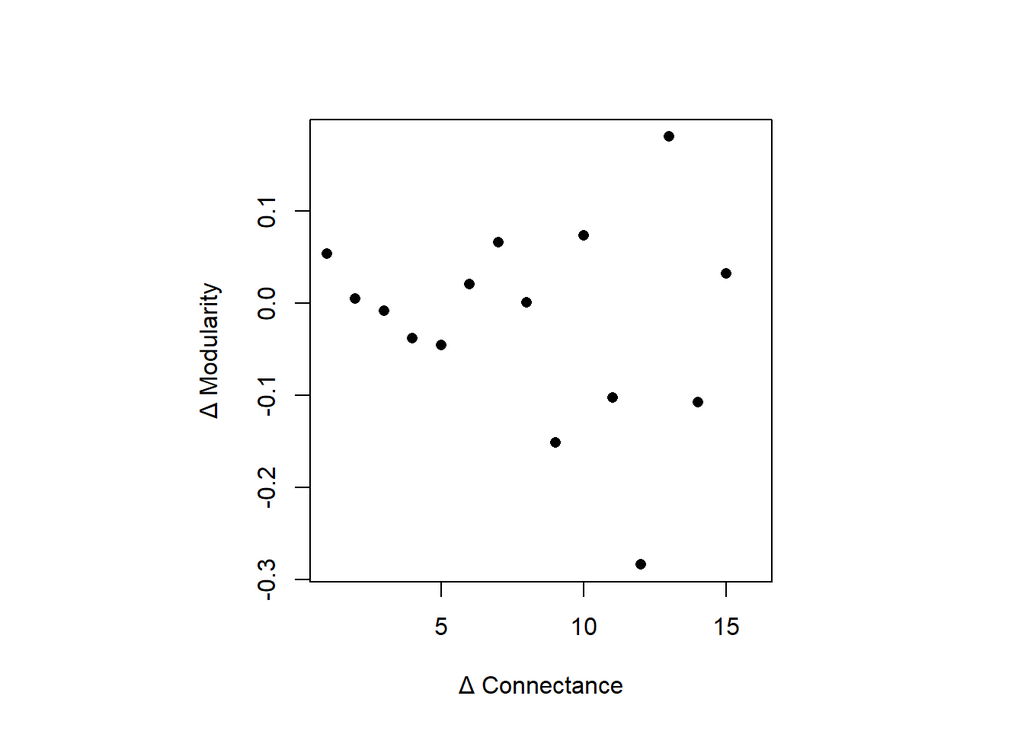

```r
par(mfrow=c(1,1), pty = "s")

plot(sum.data$web.modularity.change, sum.data$connectance.change, type="p", col="black", pch=16, xlab = "Δ Connectance", ylab = "Δ Modularity")
```

```r
cor.test(sum.data$web.modularity.change, sum.data$Connectance.change,method="spearman")
```

```
##
##  Spearman's rank correlation rho
##
## data:  sum.data$web.modularity.change and sum.data$Connectance.change
## S = 666, p-value = 0.4984
## alternative hypothesis: true rho is not equal to 0
## sample estimates:
##        rho
## -0.1892857
```

When looking at the relationship between Δ Mod and Δ Conn, there is a negative correlation but not significant.

#### 11.3. Climate vs Connectance Correlations

Raw Data: Climate vs Connectance Correlations and Plots

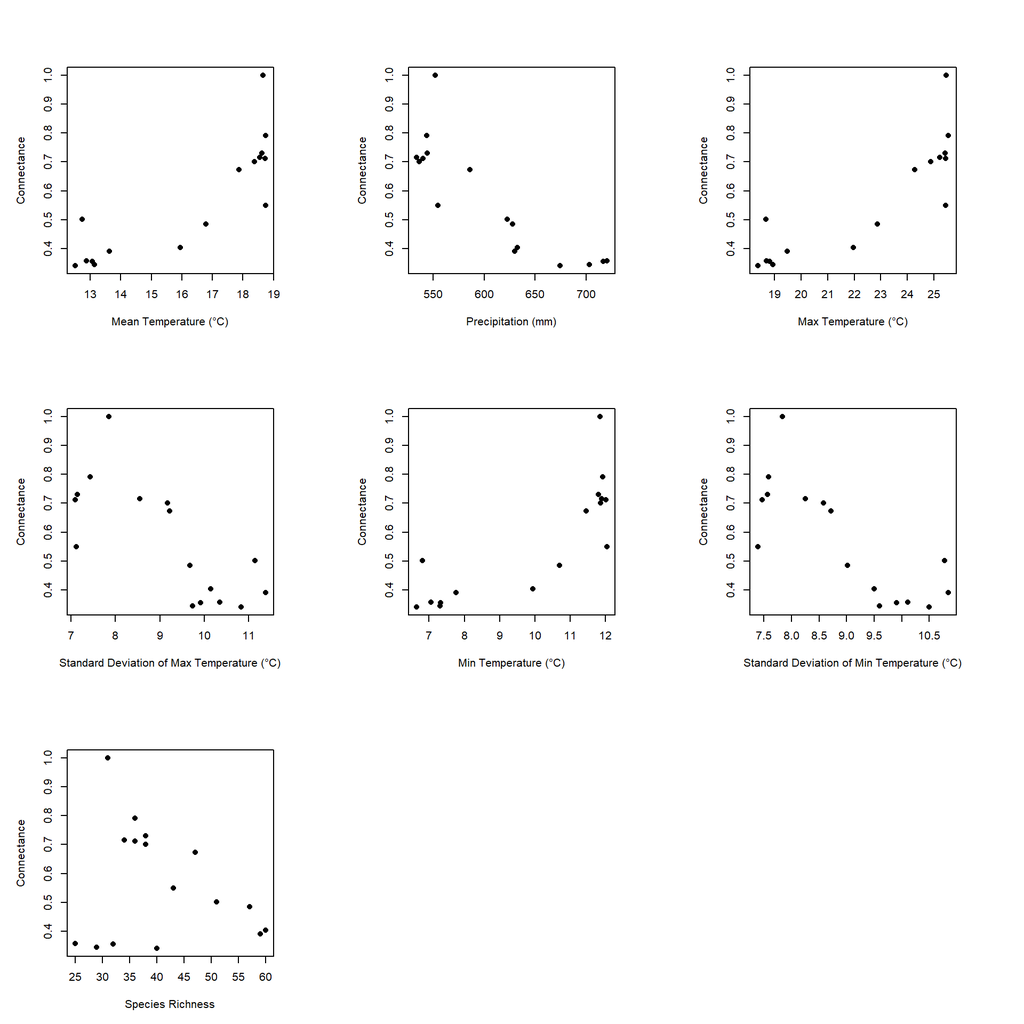

```r
par(mfrow=c(3,3), mar=c(5,5,5,5), pty = "s")

plot(sum.data$Tavg, sum.data$connectance, type="p", col="black", pch=16, xlab = "Mean Temperature (°C)", ylab = "Connectance")

plot(sum.data$Pr, sum.data$connectance, type="p", col="black", pch=16, xlab = "Precipitation (mm)", ylab = "Connectance")

plot(sum.data$Tmax, sum.data$connectance, type="p", col="black", pch=16, xlab = "Max Temperature (°C)", ylab = "Connectance")

plot(sum.data$Tmax_SD, sum.data$connectance, type="p", col="black", pch=16, xlab = "Standard Deviation of Max Temperature (°C)", ylab = "Connectance")

plot(sum.data$Tmin, sum.data$connectance, type="p", col="black", pch=16, xlab = "Min Temperature (°C)", ylab = "Connectance")

plot(sum.data$Tmin_SD, sum.data$connectance, type="p", col="black", pch=16, xlab = "Standard Deviation of Min Temperature (°C)", ylab = "Connectance")

plot(sum.data$spp.richness, sum.data$connectance, type="p", col="black", pch=16, xlab = "Species Richness", ylab = "Connectance")

# cor.test(sum.data$Tavg, sum.data$connectance,method="spearman");
# cor.test(sum.data$Pr, sum.data$connectance,method="spearman");
# cor.test(sum.data$Tmax, sum.data$connectance,method="spearman");
# cor.test(sum.data$Tmax_SD, sum.data$connectance,method="spearman");
# cor.test(sum.data$Tmin, sum.data$connectance,method="spearman");
# cor.test(sum.data$Tmin_SD, sum.data$connectance,method="spearman");
# cor.test(sum.data$Tmax_SD, sum.data$connectance,method="spearman");
# cor.test(sum.data$spp.richness, sum.data$connectance,method="spearman");
```

Run spearman correlations and arrange results into table.

```r
key_stats <- c("Tavg", "Pr", "Tmax", "Tmax_SD", "Tmin", "Tmin_SD", "spp.richness");
spearman_summaries <- data.frame(stat=as.character(key_stats),rho=as.numeric(rep(0,length(key_stats))),pvalue=as.numeric(rep(0,length(key_stats))));
for (ks in 1:length(key_stats)) {
  spearman_test <- cor.test(sum.data[,match(key_stats[ks],colnames(sum.data))],sum.data$connectance,method="spearman");
spearman_summaries$rho[ks] <- round(spearman_test$estimate,3);
spearman_summaries$pvalue[ks] <- spearman_test$p.value;
if (spearman_summaries$pvalue[ks]>10^-2)  {
  spearman_summaries$pvalue[ks] <- round(spearman_summaries$pvalue[ks],3)
  } else  {
    spearman_summaries$pvalue[ks] <- round(spearman_summaries$pvalue[ks]/(10^floor(log10(spearman_summaries$pvalue[ks]))),2)*(10^floor(log10(spearman_summaries$pvalue[ks])))
  }
}
spearman_summaries$rho2 <- spearman_summaries$rho^2;

spearman_summaries
```

```
##           stat    rho   pvalue     rho2
## 1         Tavg  0.821 0.000131 0.674041
## 2           Pr -0.874      NaN 0.763876
## 3         Tmax  0.871      NaN 0.758641
## 4      Tmax_SD -0.750 0.001230 0.562500
## 5         Tmin  0.779 0.000580 0.606841
## 6      Tmin_SD -0.762 0.000926 0.580644
## 7 spp.richness -0.097 0.720000 0.009409
```

1st Difference Data: Δ Climate vs Δ Connectance Correlations and Plots

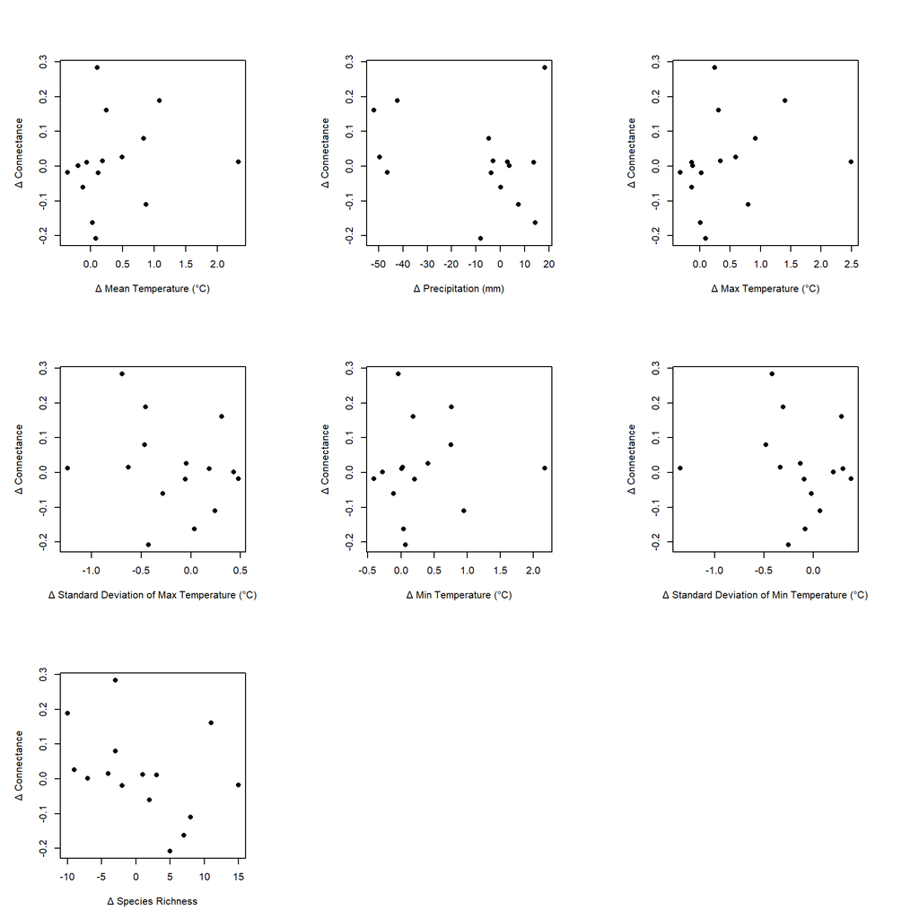

```r
par(mfrow=c(3,3), mar=c(5,5,5,5), pty = "s")

plot(sum.data$Tavg.change, sum.data$Connectance.change, type="p", col="black", pch=16, xlab = "Δ Mean Temperature (°C)", ylab = "Δ Connectance")

plot(sum.data$Pr.change, sum.data$Connectance.change, type="p", col="black", pch=16, xlab = "Δ Precipitation (mm)", ylab = "Δ Connectance")

plot(sum.data$Tmax.change, sum.data$Connectance.change, type="p", col="black", pch=16, xlab = "Δ Max Temperature (°C)", ylab = "Δ Connectance")

plot(sum.data$Tmax_SD.change, sum.data$Connectance.change, type="p", col="black", pch=16, xlab = "Δ Standard Deviation of Max Temperature (°C)", ylab = "Δ Connectance")

plot(sum.data$Tmin.change, sum.data$Connectance.change, type="p", col="black", pch=16, xlab = "Δ Min Temperature (°C)", ylab = "Δ Connectance")

plot(sum.data$Tmin_SD.change, sum.data$Connectance.change, type="p", col="black", pch=16, xlab = "Δ Standard Deviation of Min Temperature (°C)", ylab = "Δ Connectance")

plot(sum.data$spp.richness.change, sum.data$Connectance.change, type="p", col="black", pch=16, xlab = "Δ Species Richness", ylab = "Δ Connectance")



# cor.test(sum.data$Tavg.change, sum.data$Connectance.change,method="spearman")
# cor.test(sum.data$Pr.change, sum.data$Connectance.change,method="spearman")
# cor.test(sum.data$Tmax.change, sum.data$Connectance.change,method="spearman")
# cor.test(sum.data$Tmax_SD.change, sum.data$Connectance.change,method="spearman")
# cor.test(sum.data$Tmin.change, sum.data$Connectance.change,method="spearman")
# cor.test(sum.data$Tmin_SD.change, sum.data$Connectance.change,method="spearman")
# cor.test(sum.data$Tmax_SD.change, sum.data$Connectance.change,method="spearman")
# cor.test(sum.data$spp.richness.change, sum.data$Connectance.change,method="spearman")
```

Run spearman correlations and arrange results into table.

```r
key_stats <- c("Tavg.change", "Pr.change", "Tmax.change", "Tmax_SD.change", "Tmin.change", "Tmin_SD.change", "spp.richness.change");
spearman_summaries <- data.frame(stat=as.character(key_stats),rho=as.numeric(rep(0,length(key_stats))),pvalue=as.numeric(rep(0,length(key_stats))));
for (ks in 1:length(key_stats)) {
  spearman_test <- cor.test(sum.data[,match(key_stats[ks],colnames(sum.data))],sum.data$Connectance.change,method="spearman");
spearman_summaries$rho[ks] <- round(spearman_test$estimate,3);
spearman_summaries$pvalue[ks] <- spearman_test$p.value;
if (spearman_summaries$pvalue[ks]>10^-2)  {
  spearman_summaries$pvalue[ks] <- round(spearman_summaries$pvalue[ks],3)
  } else  {
    spearman_summaries$pvalue[ks] <- round(spearman_summaries$pvalue[ks]/(10^floor(log10(spearman_summaries$pvalue[ks]))),2)*(10^floor(log10(spearman_summaries$pvalue[ks])))
  }
}
spearman_summaries$rho2 <- spearman_summaries$rho^2;

spearman_summaries
```

```
##                  stat    rho pvalue     rho2
## 1         Tavg.change  0.429  0.113 0.184041
## 2           Pr.change -0.225  0.419 0.050625
## 3         Tmax.change  0.479  0.073 0.229441
## 4      Tmax_SD.change -0.354  0.196 0.125316
## 5         Tmin.change  0.161  0.567 0.025921
## 6      Tmin_SD.change -0.368  0.178 0.135424
## 7 spp.richness.change -0.520  0.047 0.270400
```

Export as an excel file that adds to the file

```r
# write.xlsx(spearman_summaries, file = "Supplemental Data/Spearman_Correlations.xlsx",
#       sheetName = "Climate v Con", append = TRUE)
```

#### 11.4. Climate vs NOS Correlations

Raw Data: Climate vs NOS Correlations and Plots

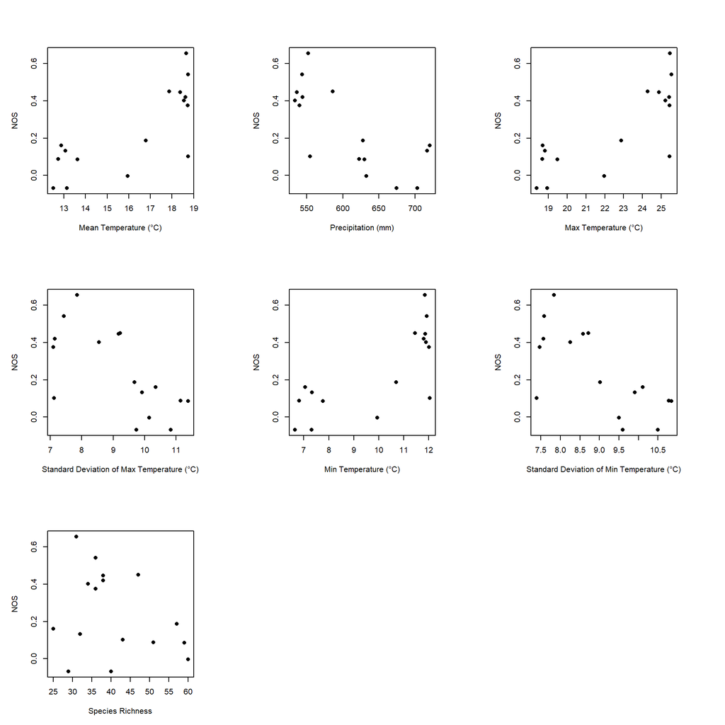

```r
par(mfrow=c(3,3), mar=c(5,5,5,5), pty = "s")

plot(sum.data$Tavg, sum.data$NOS, type="p", col="black", pch=16, xlab = "Mean Temperature (°C)", ylab = "NOS")

plot(sum.data$Pr, sum.data$NOS, type="p", col="black", pch=16, xlab = "Precipitation (mm)", ylab = "NOS")

plot(sum.data$Tmax, sum.data$NOS, type="p", col="black", pch=16, xlab = "Max Temperature (°C)", ylab = "NOS")

plot(sum.data$Tmax_SD, sum.data$NOS, type="p", col="black", pch=16, xlab = "Standard Deviation of Max Temperature (°C)", ylab = "NOS")

plot(sum.data$Tmin, sum.data$NOS, type="p", col="black", pch=16, xlab = "Min Temperature (°C)", ylab = "NOS")

plot(sum.data$Tmin_SD, sum.data$NOS, type="p", col="black", pch=16, xlab = "Standard Deviation of Min Temperature (°C)", ylab = "NOS")

plot(sum.data$spp.richness, sum.data$NOS, type="p", col="black", pch=16, xlab = "Species Richness", ylab = "NOS")

# cor.test(sum.data$Tavg, sum.data$NOS,method="spearman");
# cor.test(sum.data$Pr, sum.data$NOS,method="spearman");
# cor.test(sum.data$Tmax, sum.data$NOS,method="spearman");
# cor.test(sum.data$Tmax_SD, sum.data$NOS,method="spearman");
# cor.test(sum.data$Tmin, sum.data$NOS,method="spearman");
# cor.test(sum.data$Tmin_SD, sum.data$NOS,method="spearman");
# cor.test(sum.data$Tmax_SD, sum.data$NOS,method="spearman");
# cor.test(sum.data$spp.richness, sum.data$NOS,method="spearman");
```

Run spearman correlations and arrange results into table.

```r
key_stats <- c("Tavg", "Pr", "Tmax", "Tmax_SD", "Tmin", "Tmin_SD", "spp.richness");
spearman_summaries <- data.frame(stat=as.character(key_stats),rho=as.numeric(rep(0,length(key_stats))),pvalue=as.numeric(rep(0,length(key_stats))));
for (ks in 1:length(key_stats)) {
  spearman_test <- cor.test(sum.data[,match(key_stats[ks],colnames(sum.data))],sum.data$NOS,method="spearman");
spearman_summaries$rho[ks] <- round(spearman_test$estimate,3);
spearman_summaries$pvalue[ks] <- spearman_test$p.value;
if (spearman_summaries$pvalue[ks]>10^-2)  {
  spearman_summaries$pvalue[ks] <- round(spearman_summaries$pvalue[ks],3)
  } else  {
    spearman_summaries$pvalue[ks] <- round(spearman_summaries$pvalue[ks]/(10^floor(log10(spearman_summaries$pvalue[ks]))),2)*(10^floor(log10(spearman_summaries$pvalue[ks])))
  }
}
spearman_summaries$rho2 <- spearman_summaries$rho^2;

spearman_summaries
```

```
##           stat    rho  pvalue     rho2
## 1         Tavg  0.647 0.00822 0.418609
## 2           Pr -0.679 0.00490 0.461041
## 3         Tmax  0.721 0.00231 0.519841
## 4      Tmax_SD -0.629 0.01100 0.395641
## 5         Tmin  0.626 0.01100 0.391876
## 6      Tmin_SD -0.612 0.01400 0.374544
## 7 spp.richness -0.256 0.33800 0.065536
```

1st Difference Data: Δ Climate vs Δ NOS Correlations and Plots

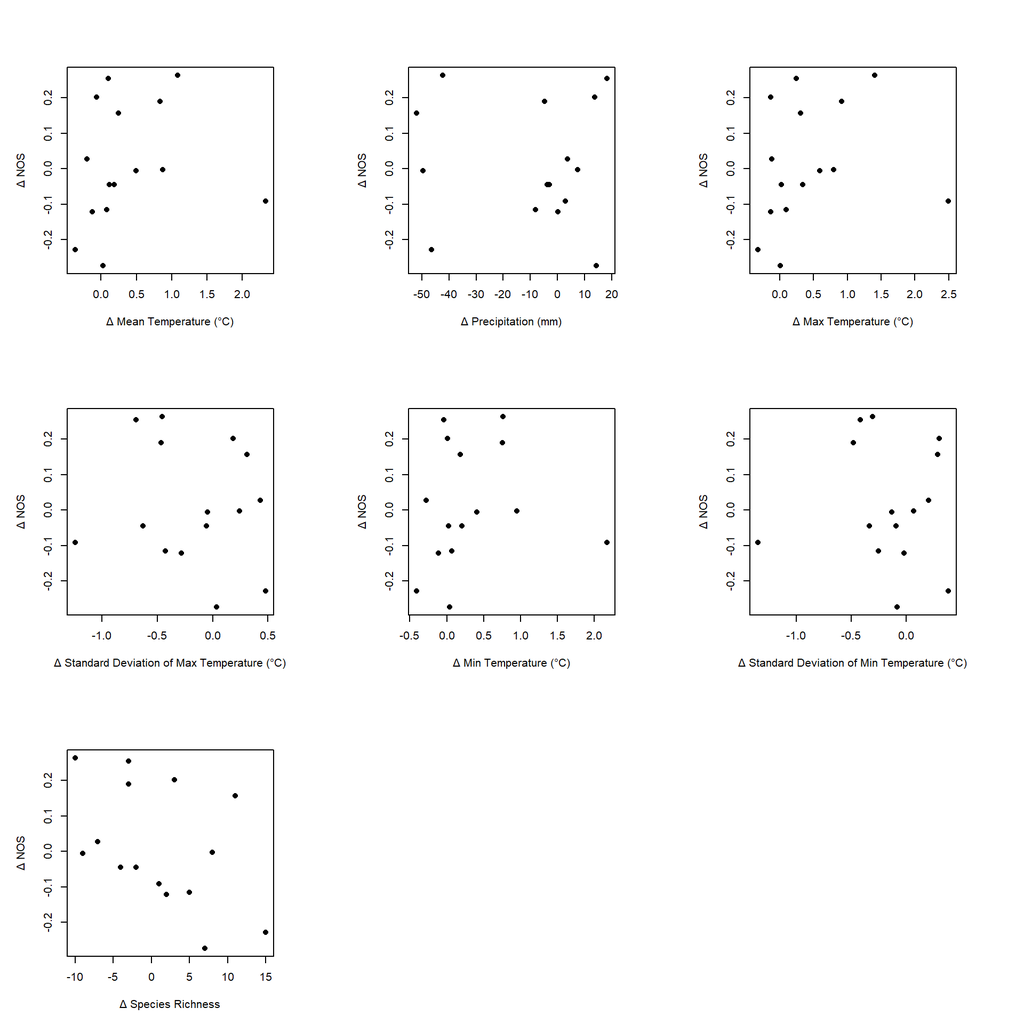

```r
par(mfrow=c(3,3), mar=c(5,5,5,5), pty = "s")

plot(sum.data$Tavg.change, sum.data$NOS.change, type="p", col="black", pch=16, xlab = "Δ Mean Temperature (°C)", ylab = "Δ NOS")

plot(sum.data$Pr.change, sum.data$NOS.change, type="p", col="black", pch=16, xlab = "Δ Precipitation (mm)", ylab = "Δ NOS")

plot(sum.data$Tmax.change, sum.data$NOS.change, type="p", col="black", pch=16, xlab = "Δ Max Temperature (°C)", ylab = "Δ NOS")

plot(sum.data$Tmax_SD.change, sum.data$NOS.change, type="p", col="black", pch=16, xlab = "Δ Standard Deviation of Max Temperature (°C)", ylab = "Δ NOS")

plot(sum.data$Tmin.change, sum.data$NOS.change, type="p", col="black", pch=16, xlab = "Δ Min Temperature (°C)", ylab = "Δ NOS")

plot(sum.data$Tmin_SD.change, sum.data$NOS.change, type="p", col="black", pch=16, xlab = "Δ Standard Deviation of Min Temperature (°C)", ylab = "Δ NOS")

plot(sum.data$spp.richness.change, sum.data$NOS.change, type="p", col="black", pch=16, xlab = "Δ Species Richness", ylab = "Δ NOS")

# cor.test(sum.data$Tavg.change, sum.data$NOS.change,method="spearman")
# cor.test(sum.data$Pr.change, sum.data$NOS.change,method="spearman")
# cor.test(sum.data$Tmax.change, sum.data$NOS.change,method="spearman")
# cor.test(sum.data$Tmax_SD.change, sum.data$NOS.change,method="spearman")
# cor.test(sum.data$Tmin.change, sum.data$NOS.change,method="spearman")
# cor.test(sum.data$Tmin_SD.change, sum.data$NOS.change,method="spearman")
# cor.test(sum.data$Tmax_SD.change, sum.data$NOS.change,method="spearman")
# cor.test(sum.data$spp.richness.change, sum.data$NOS.change,method="spearman")
```

Run spearman correlations and arrange results into table.

```r
key_stats <- c("Tavg.change", "Pr.change", "Tmax.change", "Tmax_SD.change", "Tmin.change", "Tmin_SD.change", "spp.richness.change");
spearman_summaries <- data.frame(stat=as.character(key_stats),rho=as.numeric(rep(0,length(key_stats))),pvalue=as.numeric(rep(0,length(key_stats))));
for (ks in 1:length(key_stats)) {
  spearman_test <- cor.test(sum.data[,match(key_stats[ks],colnames(sum.data))],sum.data$NOS.change,method="spearman");
spearman_summaries$rho[ks] <- round(spearman_test$estimate,3);
spearman_summaries$pvalue[ks] <- spearman_test$p.value;
if (spearman_summaries$pvalue[ks]>10^-2)  {
  spearman_summaries$pvalue[ks] <- round(spearman_summaries$pvalue[ks],3)
  } else  {
    spearman_summaries$pvalue[ks] <- round(spearman_summaries$pvalue[ks]/(10^floor(log10(spearman_summaries$pvalue[ks]))),2)*(10^floor(log10(spearman_summaries$pvalue[ks])))
  }
}
spearman_summaries$rho2 <- spearman_summaries$rho^2;

spearman_summaries
```

```
##                  stat    rho pvalue     rho2
## 1         Tavg.change  0.371  0.173 0.137641
## 2           Pr.change  0.036  0.903 0.001296
## 3         Tmax.change  0.393  0.148 0.154449
## 4      Tmax_SD.change -0.139  0.621 0.019321
## 5         Tmin.change  0.229  0.411 0.052441
## 6      Tmin_SD.change -0.146  0.602 0.021316
## 7 spp.richness.change -0.461  0.084 0.212521
```

Export as an excel file that adds to the file

```r
# write.xlsx(spearman_summaries, file = "Supplemental Data/Spearman_Correlations.xlsx",
#       sheetName = "Climate v NOS", append = TRUE)
```

## 12. Cleaning Figures

Cleaner Figures with ggplot

Raw:

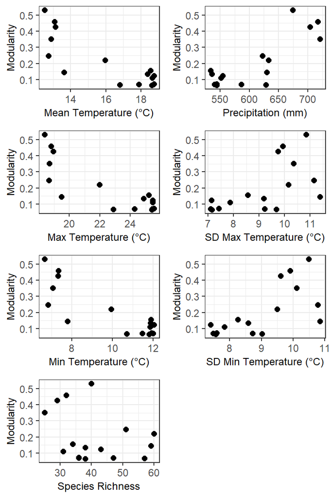

```r
p1=ggplot(sum.data, aes(x=Tavg, y=web.modularity))+
  geom_point(size=2) +
  theme_bw() +
  theme(axis.title=element_text(size=9)) +
  ylab("Modularity") +
  xlab("Mean Temperature (°C)")


p2=ggplot(sum.data, aes(x=Pr, y=web.modularity))+
  geom_point(size=2) +
  theme_bw() +
  theme(axis.title=element_text(size=9)) +
  ylab("Modularity") +
  xlab("Precipitation (mm)")

p3=ggplot(sum.data, aes(x=Tmax, y=web.modularity))+
  geom_point(size=2) +
  theme_bw() +
  theme(axis.title=element_text(size=9)) +
  ylab("Modularity") +
  xlab("Max Temperature (°C)")

p4=ggplot(sum.data, aes(x=Tmax_SD, y=web.modularity))+
  geom_point(size=2) +
  theme_bw() +
  theme(axis.title=element_text(size=9)) +
  ylab("Modularity") +
  xlab("SD Max Temperature (°C)")

p5=ggplot(sum.data, aes(x=Tmin, y=web.modularity))+
  geom_point(size=2) +
  theme_bw() +
  theme(axis.title=element_text(size=9)) +
  ylab("Modularity") +
  xlab("Min Temperature (°C)")

p6=ggplot(sum.data, aes(x=Tmin_SD, y=web.modularity))+
  geom_point(size=2) +
  theme_bw() +
  theme(axis.title=element_text(size=9)) +
  ylab("Modularity") +
  xlab("SD Min Temperature (°C)")

p7=ggplot(sum.data, aes(x=spp.richness, y=web.modularity))+
  geom_point(size=2) +
  theme_bw() +
  theme(axis.title=element_text(size=9)) +
  ylab("Modularity") +
  xlab("Species Richness")


plot_grid(p1, p2, p3, p4, p5, p6, p7, ncol=2)
```

1st Diff:

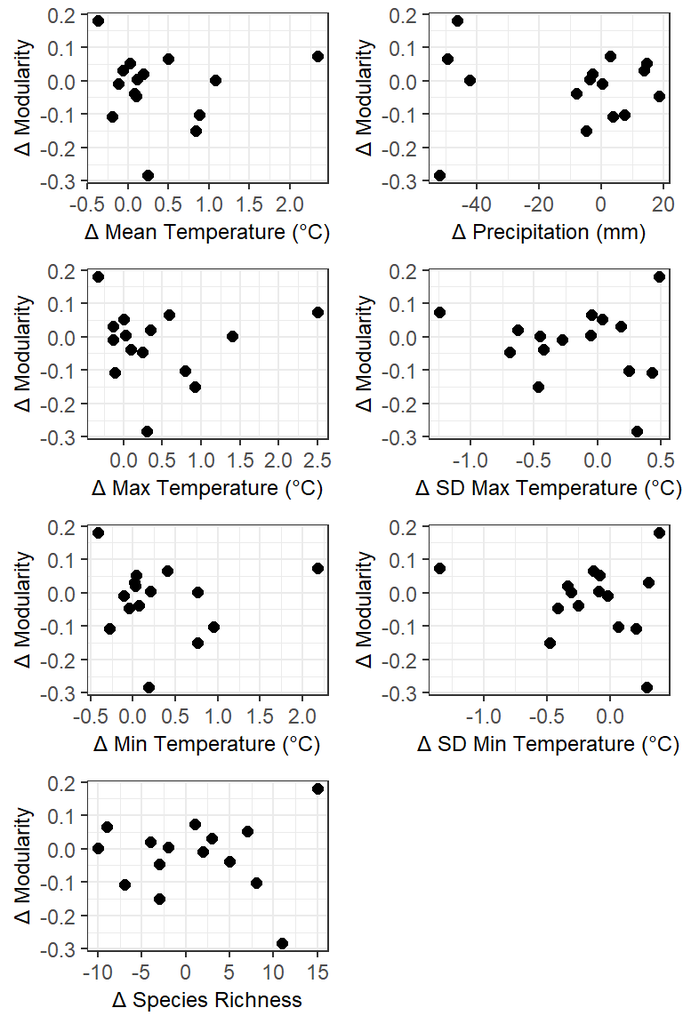

```r
p1=ggplot(sum.data, aes(x=Tavg.change, y=web.modularity.change))+
  geom_point(size=2) +
  theme_bw() +
  theme(axis.title=element_text(size=9)) +
  ylab("Δ Modularity") +
  xlab("Δ Mean Temperature (°C)")


p2=ggplot(sum.data, aes(x=Pr.change, y=web.modularity.change))+
  geom_point(size=2) +
  theme_bw() +
  theme(axis.title=element_text(size=9)) +
  ylab("Δ Modularity") +
  xlab("Δ Precipitation (mm)")

p3=ggplot(sum.data, aes(x=Tmax.change, y=web.modularity.change))+
  geom_point(size=2) +
  theme_bw() +
  theme(axis.title=element_text(size=9)) +
  ylab("Δ Modularity") +
  xlab("Δ Max Temperature (°C)")

p4=ggplot(sum.data, aes(x=Tmax_SD.change, y=web.modularity.change))+
  geom_point(size=2) +
  theme_bw() +
  theme(axis.title=element_text(size=9)) +
  ylab("Δ Modularity") +
  xlab("Δ SD Max Temperature (°C)")

p5=ggplot(sum.data, aes(x=Tmin.change, y=web.modularity.change))+
  geom_point(size=2) +
  theme_bw() +
  theme(axis.title=element_text(size=9)) +
  ylab("Δ Modularity") +
  xlab("Δ Min Temperature (°C)")

p6=ggplot(sum.data, aes(x=Tmin_SD.change, y=web.modularity.change))+
  geom_point(size=2) +
  theme_bw() +
  theme(axis.title=element_text(size=9)) +
  ylab("Δ Modularity") +
  xlab("Δ SD Min Temperature (°C)")

p7=ggplot(sum.data, aes(x=spp.richness.change, y=web.modularity.change))+
  geom_point(size=2) +
  theme_bw() +
  theme(axis.title=element_text(size=9)) +
  ylab("Δ Modularity") +
  xlab("Δ Species Richness")


plot_grid(p1, p2, p3, p4, p5, p6, p7, ncol=2)
```

Raw:

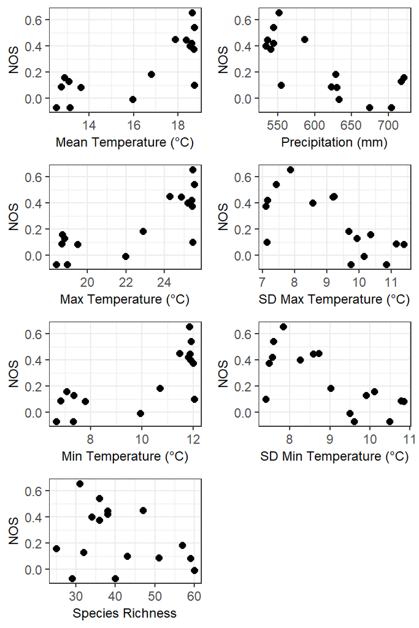

```r
p1=ggplot(sum.data, aes(x=Tavg, y=NOS))+
  geom_point(size=2) +
  theme_bw() +
  theme(axis.title=element_text(size=9)) +
  ylab("NOS") +
  xlab("Mean Temperature (°C)")


p2=ggplot(sum.data, aes(x=Pr, y=NOS))+
  geom_point(size=2) +
  theme_bw() +
  theme(axis.title=element_text(size=9)) +
  ylab("NOS") +
  xlab("Precipitation (mm)")

p3=ggplot(sum.data, aes(x=Tmax, y=NOS))+
  geom_point(size=2) +
  theme_bw() +
  theme(axis.title=element_text(size=9)) +
  ylab("NOS") +
  xlab("Max Temperature (°C)")

p4=ggplot(sum.data, aes(x=Tmax_SD, y=NOS))+
  geom_point(size=2) +
  theme_bw() +
  theme(axis.title=element_text(size=9)) +
  ylab("NOS") +
  xlab("SD Max Temperature (°C)")

p5=ggplot(sum.data, aes(x=Tmin, y=NOS))+
  geom_point(size=2) +
  theme_bw() +
  theme(axis.title=element_text(size=9)) +
  ylab("NOS") +
  xlab("Min Temperature (°C)")

p6=ggplot(sum.data, aes(x=Tmin_SD, y=NOS))+
  geom_point(size=2) +
  theme_bw() +
  theme(axis.title=element_text(size=9)) +
  ylab("NOS") +
  xlab("SD Min Temperature (°C)")

p7=ggplot(sum.data, aes(x=spp.richness, y=NOS))+
  geom_point(size=2) +
  theme_bw() +
  theme(axis.title=element_text(size=9)) +
  ylab("NOS") +
  xlab("Species Richness")


plot_grid(p1, p2, p3, p4, p5, p6, p7, ncol=2)
```

1st Diff:

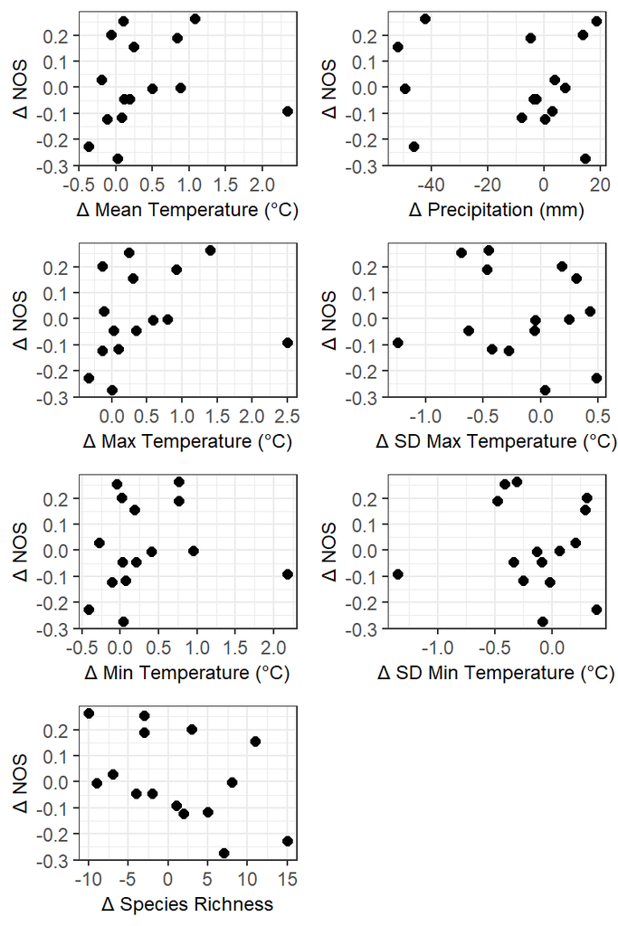

```r
p1=ggplot(sum.data, aes(x=Tavg.change, y=NOS.change))+
  geom_point(size=2) +
  theme_bw() +
  theme(axis.title=element_text(size=9)) +
  ylab("Δ NOS") +
  xlab("Δ Mean Temperature (°C)")


p2=ggplot(sum.data, aes(x=Pr.change, y=NOS.change))+
  geom_point(size=2) +
  theme_bw() +
  theme(axis.title=element_text(size=9)) +
  ylab("Δ NOS") +
  xlab("Δ Precipitation (mm)")

p3=ggplot(sum.data, aes(x=Tmax.change, y=NOS.change))+
  geom_point(size=2) +
  theme_bw() +
  theme(axis.title=element_text(size=9)) +
  ylab("Δ NOS") +
  xlab("Δ Max Temperature (°C)")

p4=ggplot(sum.data, aes(x=Tmax_SD.change, y=NOS.change))+
  geom_point(size=2) +
  theme_bw() +
  theme(axis.title=element_text(size=9)) +
  ylab("Δ NOS") +
  xlab("Δ SD Max Temperature (°C)")

p5=ggplot(sum.data, aes(x=Tmin.change, y=NOS.change))+
  geom_point(size=2) +
  theme_bw() +
  theme(axis.title=element_text(size=9)) +
  ylab("Δ NOS") +
  xlab("Δ Min Temperature (°C)")

p6=ggplot(sum.data, aes(x=Tmin_SD.change, y=NOS.change))+
  geom_point(size=2) +
  theme_bw() +
  theme(axis.title=element_text(size=9)) +
  ylab("Δ NOS") +
  xlab("Δ SD Min Temperature (°C)")

p7=ggplot(sum.data, aes(x=spp.richness.change, y=NOS.change))+
  geom_point(size=2) +
  theme_bw() +
  theme(axis.title=element_text(size=9)) +
  ylab("Δ NOS") +
  xlab("Δ Species Richness")


plot_grid(p1, p2, p3, p4, p5, p6, p7, ncol=2)
```

Raw:

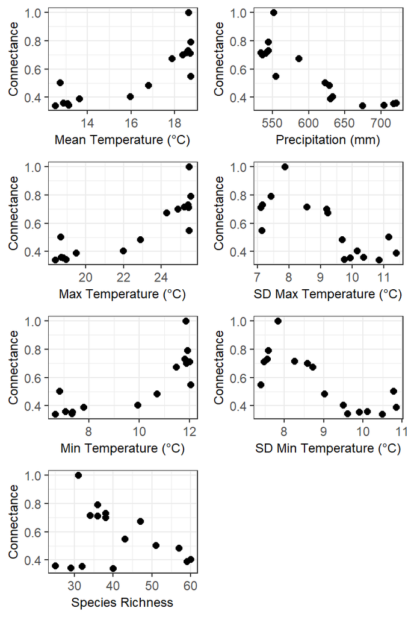

```r
p1=ggplot(sum.data, aes(x=Tavg, y=connectance))+
  geom_point(size=2) +
  theme_bw() +
  theme(axis.title=element_text(size=9)) +
  ylab("Connectance") +
  xlab("Mean Temperature (°C)")


p2=ggplot(sum.data, aes(x=Pr, y=connectance))+
  geom_point(size=2) +
  theme_bw() +
  theme(axis.title=element_text(size=9)) +
  ylab("Connectance") +
  xlab("Precipitation (mm)")

p3=ggplot(sum.data, aes(x=Tmax, y=connectance))+
  geom_point(size=2) +
  theme_bw() +
  theme(axis.title=element_text(size=9)) +
  ylab("Connectance") +
  xlab("Max Temperature (°C)")

p4=ggplot(sum.data, aes(x=Tmax_SD, y=connectance))+
  geom_point(size=2) +
  theme_bw() +
  theme(axis.title=element_text(size=9)) +
  ylab("Connectance") +
  xlab("SD Max Temperature (°C)")

p5=ggplot(sum.data, aes(x=Tmin, y=connectance))+
  geom_point(size=2) +
  theme_bw() +
  theme(axis.title=element_text(size=9)) +
  ylab("Connectance") +
  xlab("Min Temperature (°C)")

p6=ggplot(sum.data, aes(x=Tmin_SD, y=connectance))+
  geom_point(size=2) +
  theme_bw() +
  theme(axis.title=element_text(size=9)) +
  ylab("Connectance") +
  xlab("SD Min Temperature (°C)")

p7=ggplot(sum.data, aes(x=spp.richness, y=connectance))+
  geom_point(size=2) +
  theme_bw() +
  theme(axis.title=element_text(size=9)) +
  ylab("Connectance") +
  xlab("Species Richness")


plot_grid(p1, p2, p3, p4, p5, p6, p7, ncol=2)
```

1st Diff:

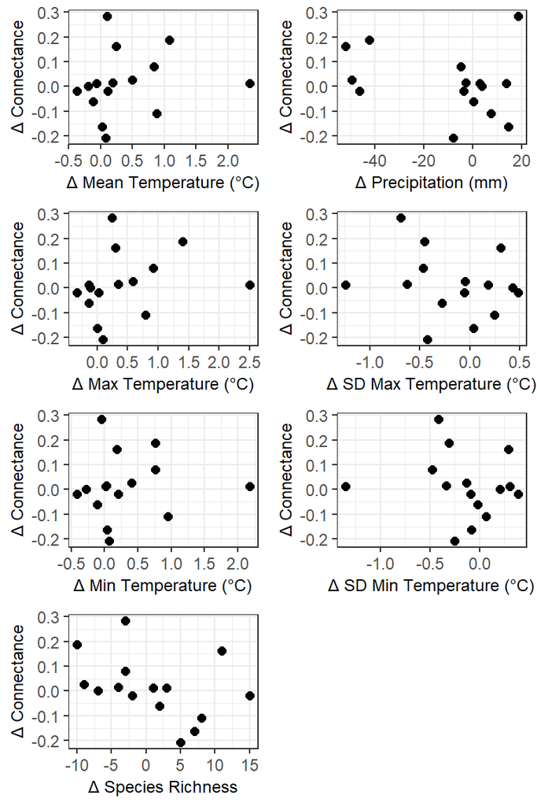

```r
p1=ggplot(sum.data, aes(x=Tavg.change, y=Connectance.change))+
  geom_point(size=2) +
  theme_bw() +
  theme(axis.title=element_text(size=9)) +
  ylab("Δ Connectance") +
  xlab("Δ Mean Temperature (°C)")


p2=ggplot(sum.data, aes(x=Pr.change, y=Connectance.change))+
  geom_point(size=2) +
  theme_bw() +
  theme(axis.title=element_text(size=9)) +
  ylab("Δ Connectance") +
  xlab("Δ Precipitation (mm)")

p3=ggplot(sum.data, aes(x=Tmax.change, y=Connectance.change))+
  geom_point(size=2) +
  theme_bw() +
  theme(axis.title=element_text(size=9)) +
  ylab("Δ Connectance") +
  xlab("Δ Max Temperature (°C)")

p4=ggplot(sum.data, aes(x=Tmax_SD.change, y=Connectance.change))+
  geom_point(size=2) +
  theme_bw() +
  theme(axis.title=element_text(size=9)) +
  ylab("Δ Connectance") +
  xlab("Δ SD Max Temperature (°C)")

p5=ggplot(sum.data, aes(x=Tmin.change, y=Connectance.change))+
  geom_point(size=2) +
  theme_bw() +
  theme(axis.title=element_text(size=9)) +
  ylab("Δ Connectance") +
  xlab("Δ Min Temperature (°C)")

p6=ggplot(sum.data, aes(x=Tmin_SD.change, y=Connectance.change))+
  geom_point(size=2) +
  theme_bw() +
  theme(axis.title=element_text(size=9)) +
  ylab("Δ Connectance") +
  xlab("Δ SD Min Temperature (°C)")

p7=ggplot(sum.data, aes(x=spp.richness.change, y=Connectance.change))+
  geom_point(size=2) +
  theme_bw() +
  theme(axis.title=element_text(size=9)) +
  ylab("Δ Connectance") +
  xlab("Δ Species Richness")


plot_grid(p1, p2, p3, p4, p5, p6, p7, ncol=2)
```

## References:

Newman M. and Girvan M. (2014). Finding and evaluating community structure in networks, Physical Review E 69, 026113

Strona, G., & Veech, J. A. (2015). A new measure of ecological network structure based on node overlap and segregation. Methods in Ecology and Evolution, 6(8), 907-915.